# Nur Nabila, S.Mat — Sertifikasi BNSP Associate Data Scientist (8 Modul Notebook)

← Kembali ke Portofolio Nur Nabila, S.Mat — Penugasan Sertifikasi BNSP Associate Data Scientist (8 Modul)

KOMPETEN BNSP Unduh File HTML

## **Penugasan untuk sleksi mahasiswa Skema Kompetensi Associate Data Scientis BNSP**

## **Nur Nabila - G5401221097**

### **Tujuan Analisis:**

Menganalisis dataset Log_Insiden_SHE yang berisi 2.699 catatan insiden periode Januari 2022 – Desember 2024. Analisis mencakup seluruh tahapan data science dari pengumpulan hingga evaluasi model prediksi, dengan output akhir berupa rekomendasi berbasis data kepada manajemen PT. Banana Coal.

```python
import pandas as pd
import numpy as np
from datetime import datetime
import os
import sys
from IPython.display import display, HTML
```

## **MODUL 1: PENGUMPULAN DATA DAN PENENTUAN OBJEK DATA**

#### a) Identifikasi tujuan analisis: menurunkan insiden LTI melalui pemodelan prediksi berbasis data historis

```python
# Tujuan Analisis
tujuan_analisis = """
Menurunkan insiden Lost Time Injury (LTI) melalui pembangunan model prediksi
berbasis data historis insiden, sehingga perusahaan dapat melakukan tindakan
pencegahan secara proaktif.
"""

print(tujuan_analisis)
```

```
Menurunkan insiden Lost Time Injury (LTI) melalui pembangunan model prediksi
berbasis data historis insiden, sehingga perusahaan dapat melakukan tindakan
pencegahan secara proaktif.
```

#### b) Tentukan sumber data: file Dataset_SHE_PTBananaCoal (sheet: Log_Insiden_SHE, 2.699 baris x 26 kolom)

```python
# Load dataset (pastikan nama file sesuai di Colab)
file_path = '/content/Dataset_SHE_PTBananaCoal (mini Project) (1).xlsx'

# Membaca sheet Log_Insiden_SHE
df = pd.read_excel(file_path, sheet_name='Log_Insiden_SHE')

# Cek dimensi data
print("Jumlah baris dan kolom:", df.shape)

# Preview data
df.head()
```

```
Jumlah baris dan kolom: (2699, 26)
```

|  | No | Tanggal | Hari | Bulan | Kuartal | Tahun | Shift | Area_Kerja | Supervisor_ID | Jenis_Pekerjaan | Jenis_Insiden | Near_Miss | First_Aid | Medical_Treatment | LTI | Fatality | Hari_Hilang_Kerja | Property_Damage | Jumlah_Tenaga_Kerja | Jam_Kerja | Kondisi_Cuaca | Penyebab_Utama | Tindakan_Korektif | Status_Tindakan | Lokasi_Spesifik | Catatan |
| --- | --- | --- | --- | --- | --- | --- | --- | --- | --- | --- | --- | --- | --- | --- | --- | --- | --- | --- | --- | --- | --- | --- | --- | --- | --- | --- |
| 0 | 1 | 2023-06-26 | Monday | 6 | Q2 | 2023 | Shift 1 (07:00-19:00) | Drainase | SPV-009 | Grading | Near Miss | 1 | 0 | 0 | 0 | 0 | 0 | 0 | 29 | 298.20 | Cerah | Komunikasi Buruk | Revisi Prosedur | Belum Dimulai | Draina-Blok02 | NaN |
| 1 | 2 | 2023-05-10 | Wednesday | 5 | Q2 | 2023 | Shift 2 (19:00-07:00) | Drainase | SPV-010 | Dozing | First Aid | 0 | 1 | 0 | 0 | 0 | 0 | 0 | 10 | 105.40 | Cerah | Alat Pelindung Diri Tidak Sesuai | Pelatihan Ulang | Dalam Proses | Draina-Blok05 | NaN |
| 2 | 3 | 2023-03-27 | Monday | 3 | Q1 | 2023 | Shift 2 (19:00-07:00) | ROM (Run of Mine) | SPV-011 | Administrasi | Near Miss | 1 | 0 | 0 | 0 | 0 | 0 | 0 | 35 | 393.70 | Cerah | Desain/Engineering | Investigasi Lanjut | Selesai | ROM (R-Blok02 | NaN |
| 3 | 4 | 2022-11-29 | Tuesday | 11 | Q4 | 2022 | Shift 2 (19:00-07:00) | Pit-C (Hauling) | SPV-020 | Loading | Medical Treatment | 0 | 0 | 1 | 0 | 0 | 0 | 0 | 22 | 258.00 | Cerah | Human Error | Revisi Prosedur | Selesai | Pit-C-Blok02 | NaN |
| 4 | 5 | 2023-05-13 | Saturday | 5 | Q2 | 2023 | Shift 2 (19:00-07:00) | Pit-B (Coal Getting) | SPV-018 | Survei | First Aid | 0 | 1 | 0 | 0 | 0 | 0 | 0 | 40 | 459.60 | Berkabut | Komunikasi Buruk | Investigasi Lanjut | Selesai | Pit-B-Blok04 | Menunggu spare part |

#### c) Identifikasi variabel-variabel yang relevan dengan tujuan prediksi LTI

##### Tidak semua kolom dalam dataset relevan untuk prediksi LTI. Diperlukan identify:

- Target variable (apa yang mau diprediksi)
- Feature variables (informasi untuk prediksi)
- Identifier variables (tracking, bukan untuk modeling)
- Irrelevant variables (tidak berguna untuk prediksi)

```python
# Melihat nama kolom
df.columns.tolist()
```

```
['No',
 'Tanggal',
 'Hari',
 'Bulan',
 'Kuartal',
 'Tahun',
 'Shift',
 'Area_Kerja',
 'Supervisor_ID',
 'Jenis_Pekerjaan',
 'Jenis_Insiden',
 'Near_Miss',
 'First_Aid',
 'Medical_Treatment',
 'LTI',
 'Fatality',
 'Hari_Hilang_Kerja',
 'Property_Damage',
 'Jumlah_Tenaga_Kerja',
 'Jam_Kerja',
 'Kondisi_Cuaca',
 'Penyebab_Utama',
 'Tindakan_Korektif',
 'Status_Tindakan',
 'Lokasi_Spesifik',
 'Catatan']
```

```python
# Pengelompokan variabel
target = ['LTI']

fitur_relevan = [
    'Shift',
    'Area_Kerja',
    'Jam_Kerja',
    'Jumlah_Tenaga_Kerja',
    'Jenis_Insiden',
    'Penyebab_Utama',
    'Kondisi_Cuaca',
    'Jenis_Pekerjaan',
    'Hari_Hilang_Kerja'
]

print("Target:", target)
print("Fitur relevan:", fitur_relevan)
```

```
Target: ['LTI']
Fitur relevan: ['Shift', 'Area_Kerja', 'Jam_Kerja', 'Jumlah_Tenaga_Kerja', 'Jenis_Insiden', 'Penyebab_Utama', 'Kondisi_Cuaca', 'Jenis_Pekerjaan', 'Hari_Hilang_Kerja']
```

##### Variabel dipilih berdasarkan relevansi terhadap faktor operasional, kondisi kerja, dan karakteristik insiden yang berpotensi mempengaruhi terjadinya LTI.

#### d) Dokumentasikan kamus data (data dictionary): nama kolom, tipe data, rentang nilai, dan makna setiap variabel

```python
# Struktur Data
df.info()
```

```
<class 'pandas.core.frame.DataFrame'>
RangeIndex: 2699 entries, 0 to 2698
Data columns (total 26 columns):
 #   Column               Non-Null Count  Dtype
---  ------               --------------  -----
 0   No                   2699 non-null   int64
 1   Tanggal              2697 non-null   object
 2   Hari                 2699 non-null   object
 3   Bulan                2699 non-null   int64
 4   Kuartal              2699 non-null   object
 5   Tahun                2699 non-null   int64
 6   Shift                2699 non-null   object
 7   Area_Kerja           2683 non-null   object
 8   Supervisor_ID        2688 non-null   object
 9   Jenis_Pekerjaan      2692 non-null   object
```

[output cut: 18 more lines]

```python
# Statistik Numerik
df.describe()
```

|  | No | Bulan | Tahun | Near_Miss | First_Aid | Medical_Treatment | LTI | Fatality | Hari_Hilang_Kerja | Property_Damage | Jumlah_Tenaga_Kerja | Jam_Kerja |
| --- | --- | --- | --- | --- | --- | --- | --- | --- | --- | --- | --- | --- |
| count | 2699.00 | 2699.00 | 2699.00 | 2699.00 | 2699.00 | 2699.00 | 2699.00 | 2699.00 | 2699.00 | 2699.00 | 2699.00 | 2699.00 |
| mean | 1350.00 | 6.47 | 2023.01 | 0.42 | 0.26 | 0.18 | 0.08 | 0.00 | 0.59 | 0.05 | 26.70 | 321.35 |
| std | 779.28 | 3.40 | 0.82 | 0.49 | 0.44 | 0.38 | 0.27 | 0.04 | 2.35 | 0.22 | 11.04 | 310.58 |
| min | 1.00 | 1.00 | 2022.00 | 0.00 | 0.00 | 0.00 | 0.00 | 0.00 | 0.00 | 0.00 | 0.00 | -100.00 |
| 25% | 675.50 | 4.00 | 2022.00 | 0.00 | 0.00 | 0.00 | 0.00 | 0.00 | 0.00 | 0.00 | 17.00 | 192.50 |
| 50% | 1350.00 | 6.00 | 2023.00 | 0.00 | 0.00 | 0.00 | 0.00 | 0.00 | 0.00 | 0.00 | 27.00 | 307.10 |
| 75% | 2024.50 | 9.00 | 2024.00 | 1.00 | 1.00 | 0.00 | 0.00 | 0.00 | 0.00 | 0.00 | 36.00 | 413.80 |
| max | 2699.00 | 12.00 | 2024.00 | 1.00 | 1.00 | 1.00 | 1.00 | 1.00 | 14.00 | 1.00 | 45.00 | 9999.00 |

```python
# Unique Value Kategori
for col in df.select_dtypes(include='object').columns:
    print(f"\nKolom: {col}")
    print(df[col].unique()[:5])
```

```
Kolom: Tanggal
['2023-06-26' '2023-05-10' '2023-03-27' '2022-11-29' '2023-05-13']

Kolom: Hari
['Monday' 'Wednesday' 'Tuesday' 'Saturday' 'Sunday']

Kolom: Kuartal
['Q2' 'Q1' 'Q4' 'Q3']

Kolom: Shift
['Shift 1 (07:00-19:00)' 'Shift 2 (19:00-07:00)' 'S2' 'Shift-2' 'Malam']

Kolom: Area_Kerja
['Drainase' 'ROM (Run of Mine)' 'Pit-C (Hauling)' 'Pit-B (Coal Getting)'
 'Pit-A (Overburden)']

Kolom: Supervisor_ID
['SPV-009' 'SPV-010' 'SPV-011' 'SPV-020' 'SPV-018']

Kolom: Jenis_Pekerjaan
['Grading' 'Dozing' 'Administrasi' 'Loading' 'Survei']

Kolom: Jenis_Insiden
['Near Miss' 'First Aid' 'Medical Treatment' 'Environmental Spill'
 'Property Damage']

Kolom: Kondisi_Cuaca
['Cerah' 'Berkabut' 'Berawan' 'Hujan Lebat' 'Hujan Ringan']

Kolom: Penyebab_Utama
['Komunikasi Buruk' 'Alat Pelindung Diri Tidak Sesuai'
 'Desain/Engineering' 'Human Error' 'Faktor Eksternal']

Kolom: Tindakan_Korektif
['Revisi Prosedur' 'Pelatihan Ulang' 'Investigasi Lanjut'
 'Perbaikan Desain' 'Briefing Safety']

Kolom: Status_Tindakan
['Belum Dimulai' 'Dalam Proses' 'Selesai' 'Overdue']

Kolom: Lokasi_Spesifik
['Draina-Blok02' 'Draina-Blok05' 'ROM (R-Blok02' 'Pit-C-Blok02'
 'Pit-B-Blok04']

Kolom: Catatan
[nan 'Menunggu spare part' 'Sudah dilaporkan ke HSE Manager'
 'Investigasi selesai' 'Perlu tindak lanjut']
```

```python
# Data Dictionary

# Copy dataframe biar aman
df_dd = df.copy()

# Fungsi untuk ambil rentang nilai
def get_range(col):
    if pd.api.types.is_numeric_dtype(col):
        return f"{col.min()} - {col.max()}"
    else:
        return f"{col.nunique()} kategori"

# Fungsi untuk contoh nilai
def get_sample(col):
    return list(col.dropna().unique()[:3])

# Membuat data dictionary
data_dictionary = pd.DataFrame({
    'Nama_Kolom': df_dd.columns,
    'Tipe_Data': df_dd.dtypes.values,
    'Jumlah_Non_Null': df_dd.notnull().sum().values,
    'Rentang/Nilai_Unik': [get_range(df_dd[col]) for col in df_dd.columns],
    'Contoh_Nilai': [get_sample(df_dd[col]) for col in df_dd.columns]
})

data_dictionary
```

|  | Nama_Kolom | Tipe_Data | Jumlah_Non_Null | Rentang/Nilai_Unik | Contoh_Nilai |
| --- | --- | --- | --- | --- | --- |
| 0 | No | int64 | 2699 | 1 - 2699 | [1, 2, 3] |
| 1 | Tanggal | object | 2697 | 1098 kategori | [2023-06-26, 2023-05-10, 2023-03-27] |
| 2 | Hari | object | 2699 | 7 kategori | [Monday, Wednesday, Tuesday] |
| 3 | Bulan | int64 | 2699 | 1 - 12 | [6, 5, 3] |
| 4 | Kuartal | object | 2699 | 4 kategori | [Q2, Q1, Q4] |
| 5 | Tahun | int64 | 2699 | 2022 - 2024 | [2023, 2022, 2024] |
| 6 | Shift | object | 2699 | 7 kategori | [Shift 1 (07:00-19:00), Shift 2 (19:00-07:00),... |
| 7 | Area_Kerja | object | 2683 | 17 kategori | [Drainase, ROM (Run of Mine), Pit-C (Hauling)] |
| 8 | Supervisor_ID | object | 2688 | 20 kategori | [SPV-009, SPV-010, SPV-011] |
| 9 | Jenis_Pekerjaan | object | 2692 | 12 kategori | [Grading, Dozing, Administrasi] |
| 10 | Jenis_Insiden | object | 2698 | 6 kategori | [Near Miss, First Aid, Medical Treatment] |
| 11 | Near_Miss | int64 | 2699 | 0 - 1 | [1, 0] |
| 12 | First_Aid | int64 | 2699 | 0 - 1 | [0, 1] |
| 13 | Medical_Treatment | int64 | 2699 | 0 - 1 | [0, 1] |
| 14 | LTI | int64 | 2699 | 0 - 1 | [0, 1] |
| 15 | Fatality | int64 | 2699 | 0 - 1 | [0, 1] |
| 16 | Hari_Hilang_Kerja | int64 | 2699 | 0 - 14 | [0, 11, 14] |
| 17 | Property_Damage | int64 | 2699 | 0 - 1 | [0, 1] |
| 18 | Jumlah_Tenaga_Kerja | int64 | 2699 | 0 - 45 | [29, 10, 35] |
| 19 | Jam_Kerja | float64 | 2699 | -100.0 - 9999.0 | [298.2, 105.4, 393.7] |
| 20 | Kondisi_Cuaca | object | 2688 | 5 kategori | [Cerah, Berkabut, Berawan] |
| 21 | Penyebab_Utama | object | 2691 | 10 kategori | [Komunikasi Buruk, Alat Pelindung Diri Tidak S... |
| 22 | Tindakan_Korektif | object | 2699 | 7 kategori | [Revisi Prosedur, Pelatihan Ulang, Investigasi... |
| 23 | Status_Tindakan | object | 2699 | 4 kategori | [Belum Dimulai, Dalam Proses, Selesai] |
| 24 | Lokasi_Spesifik | object | 2699 | 40 kategori | [Draina-Blok02, Draina-Blok05, ROM (R-Blok02] |
| 25 | Catatan | object | 1364 | 4 kategori | [Menunggu spare part, Sudah dilaporkan ke HSE ... |

```python
deskripsi_kolom = {
    'Tanggal': 'Tanggal kejadian insiden',
    'Shift': 'Shift kerja saat insiden terjadi (Shift 1 / Shift 2)',
    'Area_Kerja': 'Lokasi kerja tempat insiden terjadi',
    'Supervisor_ID': 'ID supervisor yang bertanggung jawab',
    'Jenis_Pekerjaan': 'Jenis aktivitas pekerjaan saat insiden',
    'Jenis_Insiden': 'Kategori insiden (Near Miss, LTI, dll)',
    'Jumlah_Tenaga_Kerja': 'Jumlah pekerja yang terlibat',
    'Jam_Kerja': 'Durasi jam kerja sebelum insiden',
    'Kondisi_Cuaca': 'Kondisi cuaca saat kejadian',
    'Penyebab_Utama': 'Penyebab utama terjadinya insiden',
    'Hari_Hilang_Kerja': 'Jumlah hari kerja yang hilang akibat insiden',
    'LTI': 'Indikator Lost Time Injury (0=tidak, 1=ya)',
    'Fatality': 'Indikator kematian akibat insiden (0=tidak, 1=ya)',
    'Near_Miss': 'Indikator kejadian nyaris celaka',
    'First_Aid': 'Indikator penanganan pertama',
    'Medical_Treatment': 'Indikator perawatan medis lanjutan'
}

# Tambahkan ke dataframe
data_dictionary['Deskripsi'] = data_dictionary['Nama_Kolom'].map(deskripsi_kolom)

data_dictionary
```

|  | Nama_Kolom | Tipe_Data | Jumlah_Non_Null | Rentang/Nilai_Unik | Contoh_Nilai | Deskripsi |
| --- | --- | --- | --- | --- | --- | --- |
| 0 | No | int64 | 2699 | 1 - 2699 | [1, 2, 3] | NaN |
| 1 | Tanggal | object | 2697 | 1098 kategori | [2023-06-26, 2023-05-10, 2023-03-27] | Tanggal kejadian insiden |
| 2 | Hari | object | 2699 | 7 kategori | [Monday, Wednesday, Tuesday] | NaN |
| 3 | Bulan | int64 | 2699 | 1 - 12 | [6, 5, 3] | NaN |
| 4 | Kuartal | object | 2699 | 4 kategori | [Q2, Q1, Q4] | NaN |
| 5 | Tahun | int64 | 2699 | 2022 - 2024 | [2023, 2022, 2024] | NaN |
| 6 | Shift | object | 2699 | 7 kategori | [Shift 1 (07:00-19:00), Shift 2 (19:00-07:00),... | Shift kerja saat insiden terjadi (Shift 1 / Sh... |
| 7 | Area_Kerja | object | 2683 | 17 kategori | [Drainase, ROM (Run of Mine), Pit-C (Hauling)] | Lokasi kerja tempat insiden terjadi |
| 8 | Supervisor_ID | object | 2688 | 20 kategori | [SPV-009, SPV-010, SPV-011] | ID supervisor yang bertanggung jawab |
| 9 | Jenis_Pekerjaan | object | 2692 | 12 kategori | [Grading, Dozing, Administrasi] | Jenis aktivitas pekerjaan saat insiden |
| 10 | Jenis_Insiden | object | 2698 | 6 kategori | [Near Miss, First Aid, Medical Treatment] | Kategori insiden (Near Miss, LTI, dll) |
| 11 | Near_Miss | int64 | 2699 | 0 - 1 | [1, 0] | Indikator kejadian nyaris celaka |
| 12 | First_Aid | int64 | 2699 | 0 - 1 | [0, 1] | Indikator penanganan pertama |
| 13 | Medical_Treatment | int64 | 2699 | 0 - 1 | [0, 1] | Indikator perawatan medis lanjutan |
| 14 | LTI | int64 | 2699 | 0 - 1 | [0, 1] | Indikator Lost Time Injury (0=tidak, 1=ya) |
| 15 | Fatality | int64 | 2699 | 0 - 1 | [0, 1] | Indikator kematian akibat insiden (0=tidak, 1=ya) |
| 16 | Hari_Hilang_Kerja | int64 | 2699 | 0 - 14 | [0, 11, 14] | Jumlah hari kerja yang hilang akibat insiden |
| 17 | Property_Damage | int64 | 2699 | 0 - 1 | [0, 1] | NaN |
| 18 | Jumlah_Tenaga_Kerja | int64 | 2699 | 0 - 45 | [29, 10, 35] | Jumlah pekerja yang terlibat |
| 19 | Jam_Kerja | float64 | 2699 | -100.0 - 9999.0 | [298.2, 105.4, 393.7] | Durasi jam kerja sebelum insiden |
| 20 | Kondisi_Cuaca | object | 2688 | 5 kategori | [Cerah, Berkabut, Berawan] | Kondisi cuaca saat kejadian |
| 21 | Penyebab_Utama | object | 2691 | 10 kategori | [Komunikasi Buruk, Alat Pelindung Diri Tidak S... | Penyebab utama terjadinya insiden |
| 22 | Tindakan_Korektif | object | 2699 | 7 kategori | [Revisi Prosedur, Pelatihan Ulang, Investigasi... | NaN |
| 23 | Status_Tindakan | object | 2699 | 4 kategori | [Belum Dimulai, Dalam Proses, Selesai] | NaN |
| 24 | Lokasi_Spesifik | object | 2699 | 40 kategori | [Draina-Blok02, Draina-Blok05, ROM (R-Blok02] | NaN |
| 25 | Catatan | object | 1364 | 4 kategori | [Menunggu spare part, Sudah dilaporkan ke HSE ... | NaN |

#### e) Tentukan unit analisis (baris = 1 kejadian insiden) dan periode data (Jan 2022 – Des 2024)

```python
# Konversi tanggal
df['Tanggal'] = pd.to_datetime(df['Tanggal'], errors='coerce')

# Cek periode
print("Tanggal minimum:", df['Tanggal'].min())
print("Tanggal maksimum:", df['Tanggal'].max())
```

```
Tanggal minimum: 2022-01-01 00:00:00
Tanggal maksimum: 2024-12-31 00:00:00
```

```python
unit_analisis = "1 baris merepresentasikan 1 kejadian insiden kerja"
print(unit_analisis)
```

```
1 baris merepresentasikan 1 kejadian insiden kerja
```

#### **Insight:**

Dataset yang digunakan bertujuan untuk menurunkan insiden Lost Time Injury (LTI) melalui pemodelan prediksi berbasis data historis, dengan karakteristik terdiri dari 2.699 data dan 26 variabel periode 2022–2024. Variabel dalam dataset mencakup aspek operasional (Shift, Area_Kerja, Jenis_Pekerjaan), lingkungan (Kondisi_Cuaca), karakteristik insiden (Jenis_Insiden, Penyebab_Utama), numerik (Jam_Kerja, Jumlah_Tenaga_Kerja, Hari_Hilang_Kerja), serta target (LTI, Fatality). Unit analisis adalah satu kejadian insiden per baris (event-based); secara kualitas awal terdapat potensi inkonsistensi kategori, missing values, dan ketidaksesuaian logika data, selain itu ditemukan potensi data leakage pada variabel seperti Hari_Hilang_Kerja dan Fatality yang perlu dievaluasi sebelum modeling. Secara keseluruhan dataset dinilai cukup representatif dan layak digunakan untuk membangun model klasifikasi prediktif LTI.

## **MODUL 2: TELAAH DATA (EXPLORATORY DATA ANALYSIS)**

#### Tujuan dari Exploratory Data Analysis (EDA) adalah untuk memahami karakteristik data secara menyeluruh sebelum dilakukan pemodelan, sehingga dapat mengidentifikasi pola, tren, hubungan antar variabel, serta potensi permasalahan dalam data.

### a) Hitung statistik deskriptif untuk variabel numerik (Jam_Kerja, Jumlah_Tenaga_Kerja, Hari_Hilang_Kerja)

```python
# Statistik deskriptif variabel numerik
numerik_cols = ['Jam_Kerja', 'Jumlah_Tenaga_Kerja', 'Hari_Hilang_Kerja']

df[numerik_cols].describe()
```

|  | Jam_Kerja | Jumlah_Tenaga_Kerja | Hari_Hilang_Kerja |
| --- | --- | --- | --- |
| count | 2699.00 | 2699.00 | 2699.00 |
| mean | 321.35 | 26.70 | 0.59 |
| std | 310.58 | 11.04 | 2.35 |
| min | -100.00 | 0.00 | 0.00 |
| 25% | 192.50 | 17.00 | 0.00 |
| 50% | 307.10 | 27.00 | 0.00 |
| 75% | 413.80 | 36.00 | 0.00 |
| max | 9999.00 | 45.00 | 14.00 |

##### Mendeteksi awal outlier

```python
df[numerik_cols].agg(['mean', 'median', 'min', 'max', 'std'])
```

|  | Jam_Kerja | Jumlah_Tenaga_Kerja | Hari_Hilang_Kerja |
| --- | --- | --- | --- |
| mean | 321.35 | 26.70 | 0.59 |
| median | 307.10 | 27.00 | 0.00 |
| min | -100.00 | 0.00 | 0.00 |
| max | 9999.00 | 45.00 | 14.00 |
| std | 310.58 | 11.04 | 2.35 |

#### **Insight:**

Berdasarkan hasil statistik deskriptif, variabel Jam_Kerja memiliki rata-rata sebesar 321,35 jam dengan nilai minimum -100 dan maksimum 9999, yang menunjukkan adanya **nilai tidak logis** dan **outlier ekstrem** sehingga perlu dilakukan pembersihan data. Variabel Jumlah_Tenaga_Kerja memiliki rata-rata 26,7 dengan rentang 0 hingga 45, yang relatif masih wajar meskipun terdapat nilai 0 yang perlu ditinjau lebih lanjut. Sedangkan Hari_Hilang_Kerja memiliki rata-rata rendah (0,59) dengan median 0, yang menunjukkan bahwa sebagian besar insiden tidak menyebabkan kehilangan hari kerja, namun terdapat nilai maksimum hingga 14 hari yang mengindikasikan adanya insiden dengan dampak serius. Secara keseluruhan, perbedaan yang cukup besar antara mean dan median pada beberapa variabel menunjukkan adanya distribusi yang tidak normal (skewed) dan keberadaan outlier yang perlu ditangani pada tahap data cleaning.

### b) Analisis distribusi frekuensi variabel kategorik (Shift, Area_Kerja, Jenis_Insiden, Penyebab_Utama)

```python
kategori_cols = ['Shift', 'Area_Kerja', 'Jenis_Insiden', 'Penyebab_Utama']

for col in kategori_cols:
    print(f"\nDistribusi {col}:")
    print(df[col].value_counts())
```

```
Distribusi Shift:
Shift
Shift 1 (07:00-19:00)    1402
Shift 2 (19:00-07:00)    1287
S2                          3
Malam                       3
SHIFT 1                     2
Shift-2                     1
shift1                      1
Name: count, dtype: int64

Distribusi Area_Kerja:
Area_Kerja
Pit-B (Coal Getting)    561
Pit-C (Hauling)         463
Pit-A (Overburden)      457
Workshop                306
ROM (Run of Mine)       290
Drainase                204
Stockpile               204
Office Area             178
wrkshop                   6
PIT-B                     4
ROM                       2
stock pile                2
pit a                     2
pit-a (OB)                1
WORKSHOP                  1
Hauling Road              1
pit b (coal)              1
Name: count, dtype: int64

Distribusi Jenis_Insiden:
Jenis_Insiden
Near Miss              1124
First Aid               692
Medical Treatment       488
Lost Time Injury        198
Property Damage         142
Environmental Spill      54
Name: count, dtype: int64

Distribusi Penyebab_Utama:
Penyebab_Utama
Peralatan Rusak                     298
Komunikasi Buruk                    277
Human Error                         277
Desain/Engineering                  277
Kondisi Cuaca Buruk                 270
Housekeeping Buruk                  268
Faktor Eksternal                    264
Prosedur Tidak Diikuti              259
Alat Pelindung Diri Tidak Sesuai    257
Kelelahan Pekerja                   244
Name: count, dtype: int64
```

```python
# Dalam bentuk persentase
for col in kategori_cols:
    print(f"\nDistribusi {col} (%):")
    print(df[col].value_counts(normalize=True) * 100)
```

```
Distribusi Shift (%):
Shift
Shift 1 (07:00-19:00)   51.95
Shift 2 (19:00-07:00)   47.68
S2                       0.11
Malam                    0.11
SHIFT 1                  0.07
Shift-2                  0.04
shift1                   0.04
Name: proportion, dtype: float64

Distribusi Area_Kerja (%):
Area_Kerja
Pit-B (Coal Getting)   20.91
Pit-C (Hauling)        17.26
Pit-A (Overburden)     17.03
Workshop               11.41
ROM (Run of Mine)      10.81
Drainase                7.60
Stockpile               7.60
Office Area             6.63
wrkshop                 0.22
PIT-B                   0.15
ROM                     0.07
stock pile              0.07
pit a                   0.07
pit-a (OB)              0.04
WORKSHOP                0.04
Hauling Road            0.04
pit b (coal)            0.04
Name: proportion, dtype: float64

Distribusi Jenis_Insiden (%):
Jenis_Insiden
Near Miss             41.66
First Aid             25.65
Medical Treatment     18.09
Lost Time Injury       7.34
Property Damage        5.26
Environmental Spill    2.00
Name: proportion, dtype: float64

Distribusi Penyebab_Utama (%):
Penyebab_Utama
Peralatan Rusak                    11.07
Komunikasi Buruk                   10.29
Human Error                        10.29
Desain/Engineering                 10.29
Kondisi Cuaca Buruk                10.03
Housekeeping Buruk                  9.96
Faktor Eksternal                    9.81
Prosedur Tidak Diikuti              9.62
Alat Pelindung Diri Tidak Sesuai    9.55
Kelelahan Pekerja                   9.07
Name: proportion, dtype: float64
```

#### **Insight:**

Berdasarkan analisis distribusi, variabel Shift menunjukkan bahwa insiden relatif seimbang antara Shift 1 (±51,95%) dan Shift 2 (±47,68%), namun terdapat inkonsistensi penulisan seperti “S2”, “Malam”, dan “shift1” yang mengindikasikan perlunya standarisasi data. Pada variabel Area_Kerja, insiden paling banyak terjadi di Pit-B (±20,91%), diikuti Pit-C dan Pit-A, yang menunjukkan bahwa area pit merupakan lokasi dengan risiko tertinggi dibandingkan area pendukung; variabel Jenis_Insiden didominasi oleh Near Miss (±41,66%) dan First Aid (±25,65%), sementara LTI hanya sekitar 7,34%, yang menunjukkan bahwa sebagian besar insiden masih dalam kategori ringan namun tetap memiliki potensi eskalasi, sedangkan pada Penyebab_Utama, distribusi relatif merata dengan penyebab tertinggi seperti Peralatan Rusak, Komunikasi Buruk, Human Error, dan Desain/Engineering, yang mengindikasikan bahwa faktor penyebab insiden bersifat multifaktor dan tidak didominasi oleh satu faktor tunggal. Secara keseluruhan, ditemukan adanya konsentrasi insiden pada area tertentu serta inkonsistensi kategori yang perlu dibersihkan sebelum analisis lanjutan.

### c) Buat visualisasi: tren insiden per tahun dan kuartal, komposisi insiden per area kerja, heatmap insiden per hari/shift, dan distribusi penyebab utama

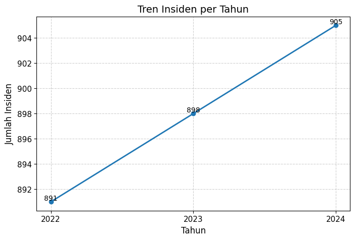

```python
# 1. Tren Insiden per tahun
import matplotlib.pyplot as plt

plt.figure(figsize=(8,5))

plt.plot(insiden_tahun.index.astype(int), insiden_tahun.values, marker='o', linewidth=2)

plt.xticks(insiden_tahun.index.astype(int), fontsize=11)
plt.yticks(fontsize=11)

plt.title("Tren Insiden per Tahun", fontsize=14)
plt.xlabel("Tahun", fontsize=12)
plt.ylabel("Jumlah Insiden", fontsize=12)

plt.grid(True, linestyle='--', alpha=0.6)

for x, y in zip(insiden_tahun.index.astype(int), insiden_tahun.values):
    plt.text(x, y, str(y), ha='center', va='bottom')  # tampilkan angka

plt.show()
```

#### **Insight:**

Jumlah insiden menunjukkan tren meningkat secara konsisten dari tahun 2022 (±891 kejadian), 2023 (±898 kejadian), hingga 2024 (±905 kejadian). Hal ini mengindikasikan bahwa upaya pengendalian keselamatan kerja belum efektif dalam menurunkan angka insiden, sehingga diperlukan strategi intervensi yang lebih tepat sasaran.

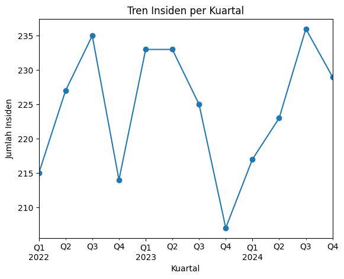

```python
# 2. Tren per kuartal
df['Kuartal'] = df['Tanggal'].dt.to_period('Q')

insiden_kuartal = df.groupby('Kuartal').size()

insiden_kuartal.plot(kind='line', marker='o')
plt.title('Tren Insiden per Kuartal')
plt.xlabel('Kuartal')
plt.ylabel('Jumlah Insiden')
plt.show()
```

#### **Insight:**

Tren per kuartal menunjukkan fluktuasi jumlah insiden, dengan beberapa puncak terjadi pada kuartal tertentu (misalnya Q3) dan penurunan signifikan pada Q4 2023. Pola ini mengindikasikan adanya faktor musiman atau operasional (seperti target produksi atau kondisi cuaca) yang mempengaruhi tingkat insiden.

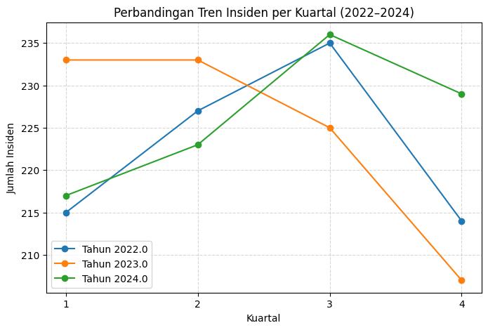

```python
# Perbandingan tren kuartal antar tahun

# Extract tahun dan kuartal
df['Tahun'] = df['Tanggal'].dt.year
df['Kuartal_num'] = df['Tanggal'].dt.quarter

# Hitung jumlah insiden per tahun & kuartal
insiden_q = df.groupby(['Tahun', 'Kuartal_num']).size().unstack()

# Plot multi-line (3 garis)
import matplotlib.pyplot as plt

plt.figure(figsize=(8,5))

for tahun in insiden_q.index:
    plt.plot(
        insiden_q.columns,
        insiden_q.loc[tahun],
        marker='o',
        label=f'Tahun {tahun}'
    )

plt.title('Perbandingan Tren Insiden per Kuartal (2022–2024)')
plt.xlabel('Kuartal')
plt.ylabel('Jumlah Insiden')
plt.xticks([1,2,3,4])
plt.legend()
plt.grid(True, linestyle='--', alpha=0.5)

plt.show()
```

#### **Insight:**

Perbandingan tren insiden per kuartal menunjukkan adanya pola fluktuasi yang berbeda antar tahun, di mana pada tahun 2022 dan 2024 terjadi peningkatan jumlah insiden hingga mencapai puncak pada kuartal 3, sedangkan pada tahun 2023 justru menunjukkan tren penurunan dari kuartal 2 hingga kuartal 4. H al ini mengindikasikan bahwa kuartal 3 merupakan periode dengan risiko insiden yang cenderung tinggi, sehingga perlu menjadi fokus utama dalam strategi pencegahan kecelakaan kerja.

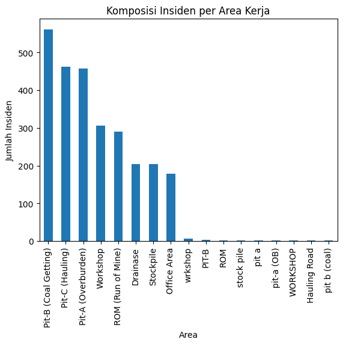

```python
# Komposisi insiden per area
df['Area_Kerja'].value_counts().plot(kind='bar')
plt.title('Komposisi Insiden per Area Kerja')
plt.xlabel('Area')
plt.ylabel('Jumlah Insiden')
plt.show()
```

#### **Insight:**

Insiden paling banyak terjadi di Pit-B (Coal Getting), diikuti oleh Pit-C dan Pit-A, yang menunjukkan bahwa area pit merupakan zona dengan risiko tertinggi dibandingkan area pendukung seperti workshop atau office. Hal ini wajar karena aktivitas di pit memiliki tingkat bahaya operasional yang lebih tinggi.

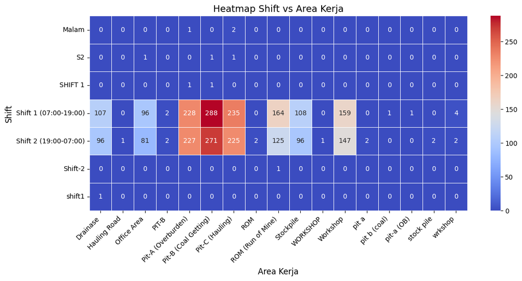

```python
import seaborn as sns
import matplotlib.pyplot as plt

# Buat pivot
pivot = pd.crosstab(df['Shift'], df['Area_Kerja'])

plt.figure(figsize=(12,6))  # diperlebar biar muat

sns.heatmap(
    pivot,
    annot=True,
    fmt='d',          # ubah dari scientific ke angka biasa
    cmap='coolwarm',
    linewidths=0.5    # biar ada garis pemisah
)

plt.title("Heatmap Shift vs Area Kerja", fontsize=14)
plt.xlabel("Area Kerja", fontsize=12)
plt.ylabel("Shift", fontsize=12)

plt.xticks(rotation=45, ha='right')  # putar label biar kebaca
plt.yticks(rotation=0)

plt.tight_layout()  # biar ga kepotong

plt.show()
```

#### **Insight:**

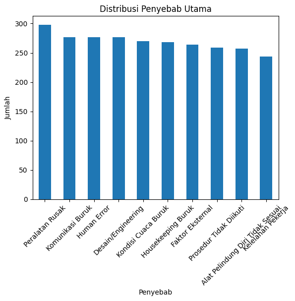

```python
# Distribusi penyebab utama
df['Penyebab_Utama'].value_counts().plot(kind='bar')
plt.title('Distribusi Penyebab Utama')
plt.xlabel('Penyebab')
plt.ylabel('Jumlah')
plt.xticks(rotation=45)
plt.show()
```

#### **Insight:**

Distribusi penyebab utama menunjukkan bahwa faktor seperti Peralatan Rusak, Komunikasi Buruk, Human Error, dan Desain/Engineering memiliki jumlah kejadian yang relatif tinggi dan hampir seimbang. Hal ini mengindikasikan bahwa insiden tidak disebabkan oleh satu faktor dominan, melainkan merupakan kombinasi berbagai faktor risiko (multifaktor).

### d) Kalkulasi indikator kinerja SHE: TRIR, LTIR, dan Severity Rate per tahun/area

#### **Rumus:**

- TRIR = (Total Incident / Total Jam Kerja) × 1,000,000
- LTIR = (Total LTI / Total Jam Kerja) × 1,000,000
- Severity Rate = (Hari Hilang / Total Jam Kerja) × 1,000,000

```python
# Total per tahun
she_yearly = df.groupby('Tahun').agg({
    'Jam_Kerja': 'sum',
    'LTI': 'sum',
    'Hari_Hilang_Kerja': 'sum'
})

she_yearly['Total_Insiden'] = df.groupby('Tahun').size()

# Hitung indikator
she_yearly['TRIR'] = (she_yearly['Total_Insiden'] / she_yearly['Jam_Kerja']) * 1_000_000
she_yearly['LTIR'] = (she_yearly['LTI'] / she_yearly['Jam_Kerja']) * 1_000_000
she_yearly['Severity_Rate'] = (she_yearly['Hari_Hilang_Kerja'] / she_yearly['Jam_Kerja']) * 1_000_000

she_yearly
```

| Tahun | Jam_Kerja | LTI | Hari_Hilang_Kerja | Total_Insiden | TRIR | LTIR | Severity_Rate |
| --- | --- | --- | --- | --- | --- | --- | --- |
| 2022.00 | 287504.60 | 63 | 468 | 891 | 3099.08 | 219.13 | 1627.80 |
| 2023.00 | 291498.40 | 73 | 572 | 898 | 3080.63 | 250.43 | 1962.27 |
| 2024.00 | 286500.00 | 75 | 560 | 905 | 3158.81 | 261.78 | 1954.62 |

#### **Insight:**

Berdasarkan hasil perhitungan, nilai TRIR menunjukkan tren yang relatif stabil namun cenderung meningkat dari tahun 2022 (±3099) ke 2024 (±3158) yang mengindikasikan bahwa frekuensi insiden per jam kerja belum mengalami perbaikan signifikan. Nilai LTIR mengalami peningkatan cukup jelas dari 219 menjadi 261 yang menunjukkan bahwa insiden dengan dampak kehilangan waktu kerja semakin meningkat dan menjadi perhatian utama. Sementara itu, Severity Rate meningkat dari 1627 pada 2022 ke puncaknya di 1962 pada 2023, lalu sedikit menurun di 2024 (±1954), namun tetap lebih tinggi dibanding tahun awal yang mengindikasikan bahwa tingkat keparahan insiden masih tinggi. Secara keseluruhan, ketiga indikator ini menunjukkan bahwa baik frekuensi maupun dampak insiden belum terkendali dengan baik, sehingga diperlukan peningkatan strategi keselamatan kerja yang lebih efektif dan terfokus.

### e) Identifikasi pola dan anomali: area/shift/supervisor dengan frekuensi insiden tinggi

```python
# Area dengan insiden tertinggi
df['Area_Kerja'].value_counts().head()
```

| Area_Kerja | count |
| --- | --- |
| Pit-B (Coal Getting) | 561 |
| Pit-C (Hauling) | 463 |
| Pit-A (Overburden) | 457 |
| Workshop | 306 |
| ROM (Run of Mine) | 290 |

**dtype:** int64

#### **Insgiht:**

Insiden paling banyak terjadi di Pit-B (561 kejadian), diikuti oleh Pit-C dan Pit-A yang menunjukkan bahwa aktivitas di area pit merupakan sumber risiko utama dibandingkan area pendukung seperti workshop atau ROM. Hal ini mengindikasikan bahwa proses operasional utama seperti coal getting, hauling, dan overburden memiliki tingkat bahaya yang lebih tinggi sehingga perlu menjadi prioritas dalam pengendalian risiko.

```python
# Shift paling berisiko
df['Shift'].value_counts()
```

| Shift | count |
| --- | --- |
| Shift 1 (07:00-19:00) | 1402 |
| Shift 2 (19:00-07:00) | 1287 |
| S2 | 3 |
| Malam | 3 |
| SHIFT 1 | 2 |
| Shift-2 | 1 |
| shift1 | 1 |

**dtype:** int64

#### **Insight:**

Distribusi insiden antara Shift 1 (1402) dan Shift 2 (1287) relatif seimbang, namun sedikit lebih tinggi pada Shift 1. Selain itu, terdapat variasi penulisan seperti “S2”, “Malam”, dan “shift1” yang menunjukkan adanya inkonsistensi data. Secara operasional, hal ini menunjukkan bahwa risiko insiden terjadi di kedua shift, sehingga pengawasan keselamatan perlu diterapkan secara konsisten di semua waktu kerja.

```python
# Supervisor dengan insiden terbanyak
df['Supervisor_ID'].value_counts().head()
```

| Supervisor_ID | count |
| --- | --- |
| SPV-003 | 159 |
| SPV-010 | 154 |
| SPV-018 | 146 |
| SPV-009 | 146 |
| SPV-015 | 144 |

**dtype:** int64

#### **Insight:**

Supervisor dengan jumlah insiden tertinggi adalah SPV-003 (159 kejadian), diikuti oleh SPV-010 dan SPV lainnya. Hal ini mengindikasikan adanya perbedaan tingkat risiko atau efektivitas pengawasan antar supervisor, yang dapat disebabkan oleh faktor seperti jenis pekerjaan yang ditangani, area kerja, atau kualitas implementasi prosedur keselamatan.

## **MODUL 3: VALIDASI DATA**

### a) Periksa kelengkapan data: hitung persentase missing values per kolom

```python
# Persentase missing values per kolom
missing = df.isnull().sum()
missing_percent = (missing / len(df)) * 100

missing_df = pd.DataFrame({
    'Jumlah_Missing': missing,
    'Persentase (%)': missing_percent
})

missing_df.sort_values(by='Persentase (%)', ascending=False)
```

|  | Jumlah_Missing | Persentase (%) |
| --- | --- | --- |
| Catatan | 1335 | 49.46 |
| Area_Kerja | 16 | 0.59 |
| Supervisor_ID | 11 | 0.41 |
| Kondisi_Cuaca | 11 | 0.41 |
| Penyebab_Utama | 8 | 0.30 |
| Jenis_Pekerjaan | 7 | 0.26 |
| Tahun | 5 | 0.19 |
| Kuartal_num | 5 | 0.19 |
| Kuartal | 5 | 0.19 |
| Tanggal | 5 | 0.19 |
| Jenis_Insiden | 1 | 0.04 |
| Bulan | 0 | 0.00 |
| Shift | 0 | 0.00 |
| No | 0 | 0.00 |
| Hari | 0 | 0.00 |
| Near_Miss | 0 | 0.00 |
| First_Aid | 0 | 0.00 |
| Medical_Treatment | 0 | 0.00 |
| LTI | 0 | 0.00 |
| Jumlah_Tenaga_Kerja | 0 | 0.00 |
| Property_Damage | 0 | 0.00 |
| Hari_Hilang_Kerja | 0 | 0.00 |
| Fatality | 0 | 0.00 |
| Tindakan_Korektif | 0 | 0.00 |
| Jam_Kerja | 0 | 0.00 |
| Lokasi_Spesifik | 0 | 0.00 |
| Status_Tindakan | 0 | 0.00 |

#### **Insight:**

Berdasarkan hasil pengecekan, sebagian besar variabel memiliki tingkat kelengkapan data yang sangat baik (missing 0%), namun terdapat satu kolom dengan missing cukup tinggi yaitu Catatan (±49,46%), yang menunjukkan bahwa kolom ini bersifat tidak kritis untuk analisis. Sementara itu, beberapa kolom lain seperti Area_Kerja, Kondisi_Cuaca, Supervisor_ID, dan Penyebab_Utama memiliki missing dalam jumlah kecil (<1%) yang masih dapat ditangani melalui imputasi. Secara keseluruhan, dataset memiliki kualitas kelengkapan yang baik dan layak digunakan untuk analisis lanjutan.

### b) Periksa duplikasi baris data

```python
# Cek jumlah duplikat
duplikat = df.duplicated().sum()
print("Jumlah data duplikat:", duplikat)
```

```
Jumlah data duplikat: 0
```

#### **Insight:**

Hasil pengecekan menunjukkan bahwa tidak terdapat data duplikat (0 data) dalam dataset, sehingga dapat disimpulkan bahwa setiap baris data merepresentasikan kejadian insiden yang unik dan tidak terdapat redundansi data yang berpotensi menyebabkan bias dalam analisis.

### c) Validasi konsistensi logis: LTI=1 harus memiliki Hari_Hilang_Kerja > 0; Fatality=1 harus LTI=1

```python
# 1. LTI = 1 → Hari_Hilang_Kerja > 0

tidak_konsisten_lti = df[(df['LTI'] == 1) & (df['Hari_Hilang_Kerja'] == 0)]
print("Jumlah data tidak konsisten (LTI tanpa hari hilang):", len(tidak_konsisten_lti))
```

```
Jumlah data tidak konsisten (LTI tanpa hari hilang): 13
```

#### **Insight:**

Ditemukan sebanyak 13 data tidak konsisten di mana nilai LTI = 1 namun Hari_Hilang_Kerja = 0, yang bertentangan dengan definisi LTI sebagai insiden yang menyebabkan kehilangan hari kerja. Hal ini menunjukkan adanya kesalahan pencatatan atau input data yang perlu diperbaiki atau dihapus.

```python
# 2. Fatality = 1 → LTI = 1

tidak_konsisten_fatal = df[(df['Fatality'] == 1) & (df['LTI'] == 0)]
print("Jumlah data tidak konsisten (Fatality tanpa LTI):", len(tidak_konsisten_fatal))
```

```
Jumlah data tidak konsisten (Fatality tanpa LTI): 0
```

#### **Insight:**

Tidak ditemukan data tidak konsisten antara Fatality dan LTI (0 kasus) yang menunjukkan bahwa hubungan logis antara kedua variabel tersebut telah sesuai dengan definisi, yaitu setiap fatality selalu termasuk dalam kategori LTI.

### d) Nilai kecukupan data: apakah jumlah sampel cukup untuk membangun model klasifikasi LTI?

```python
# Distribusi target LTI
df['LTI'].value_counts()
```

| LTI | count |
| --- | --- |
| 0 | 2488 |
| 1 | 211 |

**dtype:** int64

```python
# Persentase
df['LTI'].value_counts(normalize=True) * 100
```

| LTI | proportion |
| --- | --- |
| 0 | 92.18 |
| 1 | 7.82 |

**dtype:** float64

#### **Insight:**

Distribusi target menunjukkan bahwa kelas tidak LTI (0) mendominasi sebesar ±92,18%, sedangkan kelas LTI (1) hanya sekitar ±7,82%, yang menunjukkan adanya class imbalance yang cukup signifikan. Meskipun jumlah total data (2699) sudah cukup untuk pemodelan, ketidakseimbangan ini berpotensi menyebabkan model bias terhadap kelas mayoritas, sehingga perlu dilakukan penanganan seperti oversampling, undersampling, atau pemberian bobot kelas.

### e) Susun rekomendasi validasi: variabel mana yang perlu perbaikan dan strategi penanganannya

##### Berdasarkan hasil validasi, dataset memiliki kualitas yang cukup baik namun terdapat beberapa hal yang perlu diperbaiki, yaitu:

- Kolom Catatan memiliki missing tinggi sehingga dapat diabaikan atau dihapus karena tidak signifikan terhadap analisis
- Beberapa kolom dengan missing kecil seperti Area_Kerja, Kondisi_Cuaca, Supervisor_ID, dan Penyebab_Utama dapat ditangani dengan imputasi menggunakan modus.
- Ditemukan 13 data tidak konsisten pada LTI, sehingga perlu dilakukan perbaikan atau penghapusan untuk menjaga validitas data
- Selain itu, terdapat ketidakseimbangan kelas pada variabel LTI, sehingga perlu diterapkan teknik penanganan imbalance seperti oversampling atau class weighting pada tahap pemodelan.

Secara keseluruhan, diperlukan proses data cleaning untuk memastikan kualitas data sebelum digunakan dalam model prediksi.

## **MODUL 4: PEMBERSIHAN DATA**

### a) Standarisasi kolom Shift: satukan variasi penulisan (S2, Shift-2, Malam → "Shift 2", SHIFT 1, shift1 → "Shift 1")

```python
# Standarisasi Shift
df['Shift'] = df['Shift'].str.lower().str.strip()

def clean_shift(x):
    if '1' in x:
        return 'Shift 1'
    elif '2' in x or 'malam' in x:
        return 'Shift 2'
    else:
        return x

df['Shift'] = df['Shift'].apply(clean_shift)

# Cek hasil
df['Shift'].value_counts()
```

| Shift | count |
| --- | --- |
| Shift 1 | 2692 |
| Shift 2 | 7 |

**dtype:** int64

#### **Insight:**

Distribusi menjadi sangat tidak seimbang → indikasi ada bias data atau kesalahan mapping yang perlu diperhatikan saat modeling.

### b) Standarisasi kolom Area_Kerja: satukan variasi (wrkshop → Workshop, pit a → Pit-A, stock pile → Stockpile, dll.)

```python
# Standarisasi Area Kerja
df['Area_Kerja'] = df['Area_Kerja'].str.lower().str.strip()

mapping_area = {
    'wrkshop': 'Workshop',
    'workshop': 'Workshop',
    'pit a': 'Pit-A',
    'pit-a': 'Pit-A',
    'pit a (ob)': 'Pit-A',
    'pit b': 'Pit-B',
    'pit-b': 'Pit-B',
    'pit c': 'Pit-C',
    'pit-c': 'Pit-C',
    'stock pile': 'Stockpile',
    'rom': 'ROM',
}

df['Area_Kerja'] = df['Area_Kerja'].replace(mapping_area)

# Rapikan kapital
df['Area_Kerja'] = df['Area_Kerja'].str.title()

df['Area_Kerja'].value_counts()
```

| Area_Kerja | count |
| --- | --- |
| Pit-B (Coal Getting) | 561 |
| Pit-C (Hauling) | 463 |
| Pit-A (Overburden) | 457 |
| Workshop | 313 |
| Rom (Run Of Mine) | 290 |
| Stockpile | 206 |
| Drainase | 204 |
| Office Area | 178 |
| Pit-B | 4 |
| Rom | 2 |
| Pit-A | 2 |
| Pit-A (Ob) | 1 |
| Hauling Road | 1 |
| Pit B (Coal) | 1 |

**dtype:** int64

#### **Insight:**

Standarisasi berhasil mengurangi variasi penulisan area kerja, sehingga kategori menjadi lebih konsisten dan representatif. Area dengan insiden tertinggi tetap didominasi oleh Pit-B, Pit-C, dan Pit-A, yang menunjukkan bahwa proses cleaning tidak mengubah pola utama data, melainkan hanya memperbaiki konsistensi. Namun, masih terdapat beberapa kategori minor seperti “Pit-B”, “Rom”, atau “Pit B (Coal)” yang menunjukkan perlunya penyempurnaan mapping jika ingin lebih optimal.

### c) Tangani outlier pada Jam_Kerja: nilai negatif (min = -100) dan nilai ekstrem (max = 9999) – gunakan strategi imputasi atau penghapusan yang tepat

```python
# Tandai outlier
df.loc[df['Jam_Kerja'] < 0, 'Jam_Kerja'] = None
df.loc[df['Jam_Kerja'] > 1000, 'Jam_Kerja'] = None  # batas logis

# Imputasi dengan median
median_jam = df['Jam_Kerja'].median()
df['Jam_Kerja'].fillna(median_jam, inplace=True)

# Cek ulang
df['Jam_Kerja'].describe()
```

|  | Jam_Kerja |
| --- | --- |
| count | 2699.00 |
| mean | 307.59 |
| std | 129.48 |
| min | 78.20 |
| 25% | 195.10 |
| 50% | 307.60 |
| 75% | 412.30 |
| max | 594.80 |

**dtype:** float64

#### **Insight:**

Setelah dilakukan penanganan outlier, nilai minimum dan maksimum pada variabel Jam_Kerja menjadi lebih logis (min ±78 dan max ±594), serta distribusi data menjadi lebih stabil dengan rata-rata sekitar 307 jam. Hal ini menunjukkan bahwa nilai ekstrem sebelumnya (negatif dan 9999) berhasil diatasi tanpa menghilangkan data, sehingga kualitas data meningkat dan lebih representatif terhadap kondisi sebenarnya.

### d) Tangani missing values pada kolom Catatan

```python
# Tangani missing values pada kolom Catatan
if 'Catatan' in df.columns:
    print("Jumlah missing values di kolom 'Catatan':", df['Catatan'].isnull().sum())
    # Berdasarkan insight sebelumnya, kolom ini dapat dihapus jika masih ada.
    # df.drop('Catatan', axis=1, inplace=True)
    # print("Kolom 'Catatan' telah dihapus.")
else:
    print("Kolom 'Catatan' tidak ditemukan di DataFrame. Ini konsisten dengan insight sebelumnya bahwa kolom ini dapat diabaikan atau dihapus.")
```

```
Jumlah missing values di kolom 'Catatan': 1335
```

### e) Pastikan tipe data sesuai: Tanggal sebagai datetime, variabel biner (0/1) sebagai integer

```python
# Tanggal → datetime
df['Tanggal'] = pd.to_datetime(df['Tanggal'], errors='coerce')

# Variabel biner → integer
binary_cols = ['LTI', 'Fatality', 'Near_Miss', 'First_Aid', 'Medical_Treatment']

for col in binary_cols:
    df[col] = df[col].astype(int)

# Cek tipe data
df.info()
```

```
<class 'pandas.core.frame.DataFrame'>
RangeIndex: 2699 entries, 0 to 2698
Data columns (total 27 columns):
 #   Column               Non-Null Count  Dtype
---  ------               --------------  -----
 0   No                   2699 non-null   int64
 1   Tanggal              2694 non-null   datetime64[ns]
 2   Hari                 2699 non-null   object
 3   Bulan                2699 non-null   int64
 4   Kuartal              2694 non-null   period[Q-DEC]
 5   Tahun                2694 non-null   float64
 6   Shift                2699 non-null   object
 7   Area_Kerja           2683 non-null   object
 8   Supervisor_ID        2688 non-null   object
 9   Jenis_Pekerjaan      2692 non-null   object
```

[output cut: 19 more lines]

#### **Insight:**

Tipe data pada dataset telah disesuaikan, di mana kolom Tanggal telah dikonversi menjadi datetime dan variabel biner seperti LTI, Fatality, Near Miss, First Aid, dan Medical Treatment telah diubah menjadi integer. Hal ini memastikan bahwa data siap digunakan untuk analisis statistik maupun pemodelan machine learning tanpa kendala teknis.

```python
df.info()
```

```
<class 'pandas.core.frame.DataFrame'>
RangeIndex: 2699 entries, 0 to 2698
Data columns (total 27 columns):
 #   Column               Non-Null Count  Dtype
---  ------               --------------  -----
 0   No                   2699 non-null   int64
 1   Tanggal              2694 non-null   datetime64[ns]
 2   Hari                 2699 non-null   object
 3   Bulan                2699 non-null   int64
 4   Kuartal              2694 non-null   period[Q-DEC]
 5   Tahun                2694 non-null   float64
 6   Shift                2699 non-null   object
 7   Area_Kerja           2683 non-null   object
 8   Supervisor_ID        2688 non-null   object
 9   Jenis_Pekerjaan      2692 non-null   object
```

[output cut: 19 more lines]

## **MODUL 5: KONSTRUKSI DATA (FEATURE ENGINEERING)**

### a) Hitung indikator turunan per record: TRIR, LTIR, Severity Rate (menggunakan formula yang telah ditetapkan)

```python
# Hindari pembagian nol
df['Jam_Kerja_safe'] = df['Jam_Kerja'].replace(0, 1)

# Feature turunan
df['TRIR_record'] = 1_000_000 / df['Jam_Kerja_safe']
df['LTIR_record'] = df['LTI'] * 1_000_000 / df['Jam_Kerja_safe']
df['Severity_record'] = df['Hari_Hilang_Kerja'] * 1_000_000 / df['Jam_Kerja_safe']

df[['TRIR_record', 'LTIR_record', 'Severity_record']].head()
```

|  | TRIR_record | LTIR_record | Severity_record |
| --- | --- | --- | --- |
| 0 | 3353.45 | 0.00 | 0.00 |
| 1 | 9487.67 | 0.00 | 0.00 |
| 2 | 2540.01 | 0.00 | 0.00 |
| 3 | 3875.97 | 0.00 | 0.00 |
| 4 | 2175.81 | 0.00 | 0.00 |

### **Insight:**

Fitur turunan berhasil dibuat untuk merepresentasikan tingkat risiko dan dampak insiden pada level individu, di mana nilai TRIR_record bervariasi tergantung jam kerja, sementara LTIR_record dan Severity_record bernilai nol pada sebagian besar data karena mayoritas insiden bukan LTI. Hal ini menunjukkan bahwa insiden berat relatif jarang terjadi, namun ketika terjadi akan memberikan nilai yang signifikan pada indikator tersebut.

### b) Buat fitur temporal: ekstrak Hari_dalam_Minggu, Bulan, Kuartal dari kolom Tanggal

```python
df['Hari_dalam_Minggu'] = df['Tanggal'].dt.day_name()
df['Bulan'] = df['Tanggal'].dt.month
df['Kuartal'] = df['Tanggal'].dt.to_period('Q')

df[['Tanggal', 'Hari_dalam_Minggu', 'Bulan', 'Kuartal']].head()
```

|  | Tanggal | Hari_dalam_Minggu | Bulan | Kuartal |
| --- | --- | --- | --- | --- |
| 0 | 2023-06-26 | Monday | 6.00 | 2023Q2 |
| 1 | 2023-05-10 | Wednesday | 5.00 | 2023Q2 |
| 2 | 2023-03-27 | Monday | 3.00 | 2023Q1 |
| 3 | 2022-11-29 | Tuesday | 11.00 | 2022Q4 |
| 4 | 2023-05-13 | Saturday | 5.00 | 2023Q2 |

#### **Insight:**

Fitur temporal seperti Hari_dalam_Minggu, Bulan, dan Kuartal berhasil diekstrak dari kolom tanggal, yang memungkinkan analisis pola waktu terhadap kejadian insiden. Dari sampel data terlihat variasi hari dan periode waktu yang dapat digunakan untuk mengidentifikasi tren musiman atau pola operasional tertentu.

```python
# FEATURE ENGINEERING
# 1. Rasio beban kerja
df['Jam_per_Tenaga'] = df['Jam_Kerja'] / (df['Jumlah_Tenaga_Kerja'] + 1)

# 2. Shift malam (indikasi fatigue)
df['Is_Malam'] = df['Shift'].apply(lambda x: 1 if '2' in str(x) else 0)

# 3. Area risiko tinggi
df['High_Risk_Area'] = df['Area_Kerja'].apply(lambda x: 1 if 'Pit' in str(x) else 0)

# 4. Hari kerja vs weekend
df['Is_Weekend'] = df['Hari_dalam_Minggu'].isin(['Saturday','Sunday']).astype(int)
```

### c) Encoding variabel kategorik: One-Hot Encoding atau Label Encoding untuk Shift, Area_Kerja, Kondisi_Cuaca, Penyebab_Utama, Jenis_Pekerjaan

```python
kategori_cols = ['Shift', 'Area_Kerja', 'Kondisi_Cuaca', 'Penyebab_Utama', 'Jenis_Pekerjaan']

df_encoded = pd.get_dummies(df, columns=kategori_cols, drop_first=True)

df_encoded.head()
```

|  | No | Tanggal | Hari | Bulan | Kuartal | Tahun | Supervisor_ID | Jenis_Insiden | Near_Miss | First_Aid | Medical_Treatment | LTI | Fatality | Hari_Hilang_Kerja | Property_Damage | Jumlah_Tenaga_Kerja | Jam_Kerja | Tindakan_Korektif | Status_Tindakan | Lokasi_Spesifik | Catatan | Kuartal_num | Jam_Kerja_safe | TRIR_record | LTIR_record | ... | Area_Kerja_Workshop | Kondisi_Cuaca_Berkabut | Kondisi_Cuaca_Cerah | … |
| --- | --- | --- | --- | --- | --- | --- | --- | --- | --- | --- | --- | --- | --- | --- | --- | --- | --- | --- | --- | --- | --- | --- | --- | --- | --- | --- | --- | --- | --- | --- |
| 0 | 1 | 2023-06-26 | Monday | 6.00 | 2023Q2 | 2023.00 | SPV-009 | Near Miss | 1 | 0 | 0 | 0 | 0 | 0 | 0 | 29 | 298.20 | Revisi Prosedur | Belum Dimulai | Draina-Blok02 | NaN | 2.00 | 298.20 | 3353.45 | 0.00 | ... | False | False | True | … |
| 1 | 2 | 2023-05-10 | Wednesday | 5.00 | 2023Q2 | 2023.00 | SPV-010 | First Aid | 0 | 1 | 0 | 0 | 0 | 0 | 0 | 10 | 105.40 | Pelatihan Ulang | Dalam Proses | Draina-Blok05 | NaN | 2.00 | 105.40 | 9487.67 | 0.00 | ... | False | False | True | … |
| 2 | 3 | 2023-03-27 | Monday | 3.00 | 2023Q1 | 2023.00 | SPV-011 | Near Miss | 1 | 0 | 0 | 0 | 0 | 0 | 0 | 35 | 393.70 | Investigasi Lanjut | Selesai | ROM (R-Blok02 | NaN | 1.00 | 393.70 | 2540.01 | 0.00 | ... | False | False | True | … |
| 3 | 4 | 2022-11-29 | Tuesday | 11.00 | 2022Q4 | 2022.00 | SPV-020 | Medical Treatment | 0 | 0 | 1 | 0 | 0 | 0 | 0 | 22 | 258.00 | Revisi Prosedur | Selesai | Pit-C-Blok02 | NaN | 4.00 | 258.00 | 3875.97 | 0.00 | ... | False | False | True | … |
| 4 | 5 | 2023-05-13 | Saturday | 5.00 | 2023Q2 | 2023.00 | SPV-018 | First Aid | 0 | 1 | 0 | 0 | 0 | 0 | 0 | 40 | 459.60 | Investigasi Lanjut | Selesai | Pit-B-Blok04 | Menunggu spare part | 2.00 | 459.60 | 2175.81 | 0.00 | ... | False | True | False | … |

5 rows × 69 columns

### d) Normalisasi/standarisasi variabel numerik jika diperlukan oleh algoritma yang dipilih

Algoritma yang dipilih:

- Random Forest
- XGBoost

```python
# Tidak dilakukan normalisasi karena menggunakan tree-based model
numerik_cols = ['Jam_Kerja', 'Jumlah_Tenaga_Kerja', 'Hari_Hilang_Kerja']

df_encoded[numerik_cols].describe()
```

|  | Jam_Kerja | Jumlah_Tenaga_Kerja | Hari_Hilang_Kerja |
| --- | --- | --- | --- |
| count | 2699.00 | 2699.00 | 2699.00 |
| mean | 307.59 | 26.70 | 0.59 |
| std | 129.48 | 11.04 | 2.35 |
| min | 78.20 | 0.00 | 0.00 |
| 25% | 195.10 | 17.00 | 0.00 |
| 50% | 307.60 | 27.00 | 0.00 |
| 75% | 412.30 | 36.00 | 0.00 |
| max | 594.80 | 45.00 | 14.00 |

#### **Insight:**

Normalisasi atau standarisasi tidak dilakukan pada variabel numerik karena algoritma yang digunakan dalam pemodelan adalah Random Forest dan XGBoost yang tidak sensitif terhadap skala data. Kedua algoritma tersebut berbasis decision tree yang bekerja dengan membagi data berdasarkan nilai threshold, sehingga perbedaan skala antar variabel tidak mempengaruhi performa model.

### e) Analisis korelasi antar fitur untuk menghindari multikolinearitas

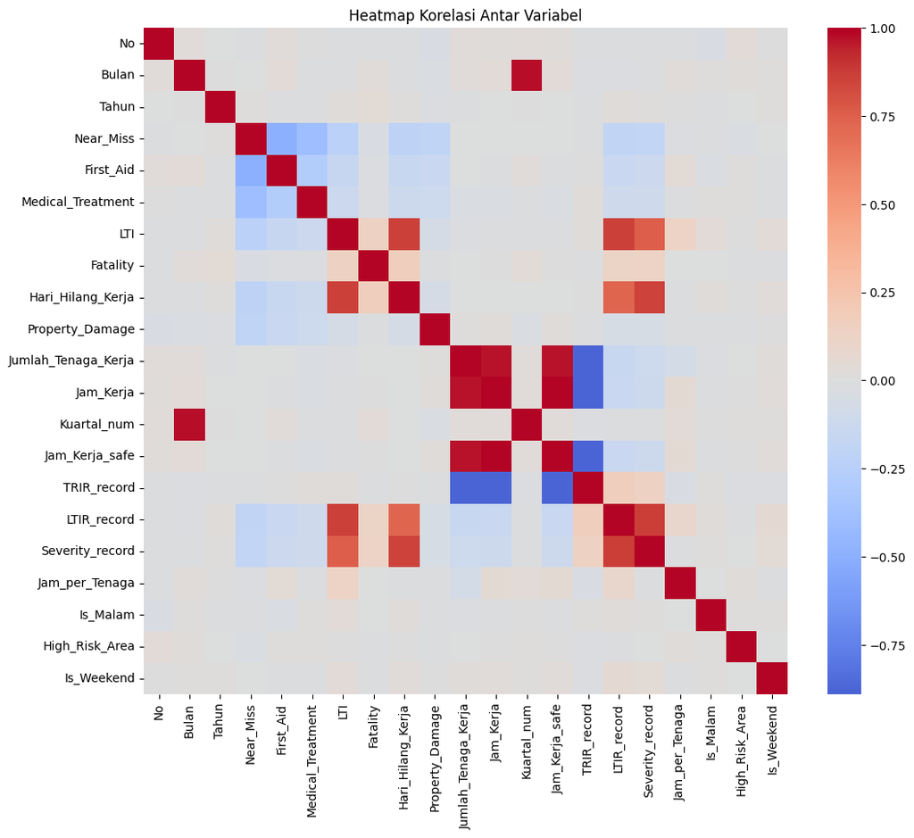

```python
import matplotlib.pyplot as plt
import seaborn as sns

# Ambil hanya kolom numerik
df_numeric = df_encoded.select_dtypes(include=['int64', 'float64'])

# Hitung korelasi
corr_matrix = df_numeric.corr()

# Plot heatmap
plt.figure(figsize=(12,10))
sns.heatmap(corr_matrix, cmap='coolwarm', center=0)
plt.title('Heatmap Korelasi Antar Variabel')
plt.show()
```

### **Insght:**

Heatmap menunjukkan adanya beberapa hubungan kuat antar variabel, khususnya antara Hari_Hilang_Kerja, LTIR_record, dan Severity_record, yang mengindikasikan adanya keterkaitan erat dalam merepresentasikan dampak insiden, selain itu, beberapa variabel memiliki korelasi rendah yang menunjukkan kontribusi independen terhadap model.

```python
# Korelasi terhadap target LTI
corr_lti = corr_matrix['LTI'].sort_values(ascending=False)

corr_lti
```

|  | LTI |
| --- | --- |
| LTI | 1.00 |
| Hari_Hilang_Kerja | 0.87 |
| LTIR_record | 0.86 |
| Severity_record | 0.75 |
| Fatality | 0.15 |
| Jam_per_Tenaga | 0.13 |
| Is_Malam | 0.04 |
| Is_Weekend | 0.04 |
| Tahun | 0.02 |
| TRIR_record | 0.02 |
| High_Risk_Area | 0.01 |
| No | -0.01 |
| Jam_Kerja | -0.01 |
| Jam_Kerja_safe | -0.01 |
| Kuartal_num | -0.01 |
| Bulan | -0.02 |
| Jumlah_Tenaga_Kerja | -0.02 |
| Property_Damage | -0.06 |
| Medical_Treatment | -0.13 |
| First_Aid | -0.16 |
| Near_Miss | -0.23 |

**dtype:** float64

### **Insght:**

Variabel yang memiliki korelasi tertinggi dengan LTI adalah:

- Hari_Hilang_Kerja (0.87)
- LTIR_record (0.86)
- Severity_record (0.75)

Namun, variabel-variabel ini memiliki hubungan langsung dengan definisi LTI sehingga mengindikasikan potensi data leakage dan perlu dipertimbangkan untuk tidak digunakan dalam model.

```python
# Top 10 fitur paling berkorelasi dengan LTI
top_features = corr_lti.abs().sort_values(ascending=False).head(10)

top_features
```

|  | LTI |
| --- | --- |
| LTI | 1.00 |
| Hari_Hilang_Kerja | 0.87 |
| LTIR_record | 0.86 |
| Severity_record | 0.75 |
| Near_Miss | 0.23 |
| First_Aid | 0.16 |
| Fatality | 0.15 |
| Medical_Treatment | 0.13 |
| Jam_per_Tenaga | 0.13 |
| Property_Damage | 0.06 |

**dtype:** float64

#### **Insight:**

Selain variabel yang berpotensi leakage, fitur lain seperti Near Miss, First Aid, dan Fatality juga menunjukkan korelasi terhadap LTI, yang mengindikasikan bahwa tingkat keparahan insiden memiliki hubungan dengan kemungkinan terjadinya LTI. Sementara itu, variabel operasional seperti Jumlah_Tenaga_Kerja memiliki korelasi yang sangat rendah, sehingga kontribusinya terhadap prediksi relatif kecil.

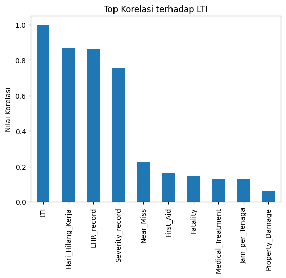

```python
top_features.plot(kind='bar')
plt.title('Top Korelasi terhadap LTI')
plt.ylabel('Nilai Korelasi')
plt.show()
```

```python
# FEATURE SELECTION

corr = X_final.corrwith(df_encoded['LTI']).abs().sort_values(ascending=False)

# pilih fitur yang relevan
selected_features = corr[corr > 0.02].index

X_final = X_final[selected_features]

print("Jumlah fitur setelah seleksi:", len(X_final.columns))
```

[output not shown]

### Pada tahap feature engineering, dilakukan pembuatan fitur turunan, ekstraksi fitur temporal, serta transformasi variabel kategorik menjadi numerik melalui encoding. Selain itu, dilakukan analisis korelasi untuk mengidentifikasi hubungan antar variabel, di mana ditemukan beberapa fitur dengan korelasi tinggi terhadap target yang berpotensi menyebabkan data leakage. Oleh karena itu, diperlukan seleksi fitur sebelum proses pemodelan untuk memastikan model yang dihasilkan lebih akurat dan tidak bias.

## **MODUL 6: PENENTUAN LABEL DATA**

### a) Tentukan variabel target (label): LTI (0 = tidak terjadi LTI, 1 = terjadi LTI)

```python
# Menentukan target
target = 'LTI'

X = df_encoded.drop(columns=[target])
y = df_encoded[target]

print("Fitur:", X.shape)
print("Target:", y.shape)
```

```
Fitur: (2699, 68)
Target: (2699,)
```

### b) Analisis distribusi kelas: hitung proporsi LTI=1 vs LTI=0 untuk mendeteksi class imbalance

```python
# Distribusi kelas
print(y.value_counts())

# Persentase
print(y.value_counts(normalize=True) * 100)
```

```
LTI
0    2488
1     211
Name: count, dtype: int64
LTI
0   92.18
1    7.82
Name: proportion, dtype: float64
```

### **Insight:**

Distribusi kelas menunjukkan bahwa kelas non-LTI (0) mendominasi sebesar ±92,18%, sedangkan kelas LTI (1) hanya ±7,82%, yang mengindikasikan adanya ketidakseimbangan kelas yang signifikan (class imbalance). Kondisi ini berpotensi menyebabkan model cenderung bias terhadap kelas mayoritas jika tidak ditangani dengan baik.

### c) Tentukan strategi penanganan class imbalance jika ada (SMOTE, oversampling, atau pembobotan kelas)

##### Menggunakan Class Weight

```python
from sklearn.model_selection import train_test_split

# Split data (stratified)
X_train, X_test, y_train, y_test = train_test_split(
    X, y,
    test_size=0.2,
    random_state=42,
    stratify=y
)

print("Distribusi data training:")
print(y_train.value_counts())

print("\nDistribusi data testing:")
print(y_test.value_counts())
```

```
Distribusi data training:
LTI
0    1990
1     169
Name: count, dtype: int64

Distribusi data testing:
LTI
0    498
1     42
Name: count, dtype: int64
```

```python
# CLASS WEIGHT

scale_pos_weight = (y_train == 0).sum() / (y_train == 1).sum()

print("Scale Pos Weight:", scale_pos_weight)
```

```
Scale Pos Weight: 11.775147928994082
```

### **Insight:**

Distribusi data menunjukkan bahwa kelas non-LTI (0) masih mendominasi baik pada data training (1990 vs 169) maupun data testing (498 vs 42), yang menegaskan adanya ketidakseimbangan kelas yang signifikan. Untuk mengatasi hal tersebut, digunakan pendekatan class weighting dengan nilai scale_pos_weight ≈ 11.78, yang berarti kelas LTI (minoritas) diberikan bobot sekitar 11 kali lebih besar dibandingkan kelas mayoritas. Pendekatan ini memungkinkan model untuk lebih memperhatikan kelas minoritas tanpa mengubah distribusi data asli, sehingga diharapkan dapat meningkatkan kemampuan model dalam mendeteksi LTI secara lebih realistis.

### d) Pilih dan justifikasi variabel prediktor (fitur input) berdasarkan relevansi domain SHE dan hasil analisis korelasi

```python
# Tampilkan korelasi terhadap LTI (dasar pemilihan)

# Korelasi terhadap target
# Gunakan df_numeric yang sudah difilter hanya kolom numerik
corr_lti = df_numeric.corr()['LTI'].sort_values(ascending=False)

# Tampilkan
print("Korelasi terhadap LTI:")
print(corr_lti)
```

```
Korelasi terhadap LTI:
LTI                    1.00
Hari_Hilang_Kerja      0.87
LTIR_record            0.86
Severity_record        0.75
Fatality               0.15
Jam_per_Tenaga         0.13
Is_Malam               0.04
Is_Weekend             0.04
Tahun                  0.02
TRIR_record            0.02
High_Risk_Area         0.01
No                    -0.01
Jam_Kerja             -0.01
Jam_Kerja_safe        -0.01
Kuartal_num           -0.01
Bulan                 -0.02
Jumlah_Tenaga_Kerja   -0.02
Property_Damage       -0.06
Medical_Treatment     -0.13
First_Aid             -0.16
Near_Miss             -0.23
Name: LTI, dtype: float64
```

```python
# Threshold korelasi tinggi (indikasi leakage)
leakage_cols = corr_lti[abs(corr_lti) > 0.7].index.tolist()

print("Fitur dengan korelasi tinggi (indikasi leakage):")
print(leakage_cols)
```

```
Fitur dengan korelasi tinggi (indikasi leakage):
['LTI', 'Hari_Hilang_Kerja', 'LTIR_record', 'Severity_record']
```

```python
# Hapus fitur leakage
X_clean = df_encoded.drop(columns=leakage_cols, errors='ignore')

print("Jumlah fitur setelah drop leakage:", X_clean.shape[1])
```

```
Jumlah fitur setelah drop leakage: 65
```

```python
# Daftar fitur utama berbasis domain (sebelum encoding)
fitur_domain = [
    'Shift',
    'Area_Kerja',
    'Kondisi_Cuaca',
    'Penyebab_Utama',
    'Jenis_Pekerjaan',
    'Jam_Kerja',
    'Jumlah_Tenaga_Kerja',
    'Hari_dalam_Minggu',
    'Bulan',
    'Kuartal'
]

# Ambil fitur hasil encoding yang sesuai
fitur_terpilih = [col for col in X_clean.columns if any(f in col for f in fitur_domain)]

X_final = X_clean[fitur_terpilih]

print("Jumlah fitur final:", X_final.shape[1])
print("\nDaftar fitur final:")
print(X_final.columns.tolist())
```

```
Jumlah fitur final: 45

Daftar fitur final:
['Bulan', 'Kuartal', 'Jumlah_Tenaga_Kerja', 'Jam_Kerja', 'Kuartal_num', 'Jam_Kerja_safe', 'Hari_dalam_Minggu', 'Shift_Shift 2', 'Area_Kerja_Hauling Road', 'Area_Kerja_Office Area', 'Area_Kerja_Pit B (Coal)', 'Area_Kerja_Pit-A', 'Area_Kerja_Pit-A (Ob)', 'Area_Kerja_Pit-A (Overburden)', 'Area_Kerja_Pi…
```

```python
# Korelasi ulang setelah seleksi

# Convert 'Kuartal' column to a numerical representation in X_final
# if it's still of Period type. This is necessary for correlation calculation.
import pandas as pd

if 'Kuartal' in X_final.columns and pd.api.types.is_period_dtype(X_final['Kuartal']):
    X_final['Kuartal'] = X_final['Kuartal'].dt.qyear * 10 + X_final['Kuartal'].dt.quarter

# One-hot encode 'Hari_dalam_Minggu' if it's still an object type
if 'Hari_dalam_Minggu' in X_final.columns and pd.api.types.is_object_dtype(X_final['Hari_dalam_Minggu']):
    X_final = pd.get_dummies(X_final, columns=['Hari_dalam_Minggu'], drop_first=True)

corr_final = X_final.corrwith(df_encoded['LTI']).sort_values(ascending=False)

print("Korelasi fitur final terhadap LTI:")
print(corr_final.head(10))
```

```
Korelasi fitur final terhadap LTI:
Kondisi_Cuaca_Hujan Ringan        0.05
Penyebab_Utama_Faktor Eksternal   0.04
Shift_Shift 2                     0.04
Hari_dalam_Minggu_Saturday        0.03
Jenis_Pekerjaan_Loading           0.03
Jenis_Pekerjaan_Dozing            0.02
Jenis_Pekerjaan_Maintenance       0.02
Area_Kerja_Pit-C (Hauling)        0.02
Hari_dalam_Minggu_Sunday          0.02
Jenis_Pekerjaan_Grading           0.02
dtype: float64
```

```python
# CEK DATA LEAKAGE

print("Cek Hari_Hilang_Kerja:")
print('Hari_Hilang_Kerja' in X_final.columns)

print("\nCek semua kolom terkait 'Hari':")
print([col for col in X_final.columns if 'Hari' in col])

print("\nCek fitur leakage lain:")
leakage_cols = ['Hari_Hilang_Kerja', 'LTIR_record', 'Severity_record']

for col in leakage_cols:
    print(col, "->", col in X_final.columns)
```

```
Cek Hari_Hilang_Kerja:
False

Cek semua kolom terkait 'Hari':
['Hari_dalam_Minggu_Monday', 'Hari_dalam_Minggu_Saturday', 'Hari_dalam_Minggu_Sunday', 'Hari_dalam_Minggu_Thursday', 'Hari_dalam_Minggu_Tuesday', 'Hari_dalam_Minggu_Wednesday']

Cek fitur leakage lain:
Hari_Hilang_Kerja -> False
LTIR_record -> False
Severity_record -> False
```

## **MODUL 7: PEMBANGUNAN MODEL PREDIKSI LTI**

### a) Bagi dataset menjadi data training (80%) dan data testing (20%) secara acak terstratum berdasarkan label LTI

```python
from sklearn.model_selection import train_test_split

X = X_final.copy()
y = df_encoded['LTI']

X_train, X_test, y_train, y_test = train_test_split(
    X, y,
    test_size=0.2,
    random_state=42,
    stratify=y
)

print("Train:", X_train.shape)
print("Test:", X_test.shape)
```

```
Train: (2159, 50)
Test: (540, 50)
```

### **Insght:**

Dataset berhasil dibagi menjadi 80% data training (2159 data) dan 20% data testing (540 data) dengan metode stratifikasi, sehingga distribusi kelas LTI tetap terjaga; hal ini memastikan model dilatih dan diuji pada data yang representatif serta mengurangi bias akibat ketidakseimbangan distribusi.

### b) Pilih minimal 2 algoritma klasifikasi yang sesuai (mis. Logistic Regression, Decision Tree, Random Forest, atau XGBoost) beserta justifikasinya

Pilih Algoritma (Random Forest & XGBoost)

Justifikasi:

- Random Forest dimana model ini Robust terhadap noise dan mampu menangani data kompleks.
- XGBoost dimana model memiliki performa tinggi dan mampu menangkap pola non-linear dengan lebih optimal

Dipilih dua algoritma yaitu Random Forest dan XGBoost karena keduanya mampu menangani data non-linear dan kompleks dimana Random Forest unggul dalam stabilitas dan robustness terhadap noise, sementara XGBoost memiliki kemampuan boosting yang dapat meningkatkan performa model dalam menangkap pola yang lebih kompleks.

### c) Latih model menggunakan data training dan lakukan hyperparameter tuning sederhana

```python
# Random Forest
from sklearn.ensemble import RandomForestClassifier

rf = RandomForestClassifier(
    random_state=42,
    n_estimators=100,
    max_depth=None,
    class_weight='balanced'
)

rf.fit(X_train, y_train)
```

```
RandomForestClassifier(class_weight='balanced', random_state=42)
```

```python
# MODEL TUNING

from xgboost import XGBClassifier

xgb = XGBClassifier(
    n_estimators=300,
    max_depth=6,
    learning_rate=0.05,
    subsample=0.8,
    colsample_bytree=0.8,
    scale_pos_weight=scale_pos_weight,
    eval_metric='logloss',
    random_state=42
)

xgb.fit(X_train, y_train)
```

```
XGBClassifier(base_score=None, booster=None, callbacks=None,
              colsample_bylevel=None, colsample_bynode=None,
              colsample_bytree=0.8, device=None, early_stopping_rounds=None,
              enable_categorical=False, eval_metric='logloss',
              feature_types=None, feature_weights=None, gamma=None,
              grow_policy=None, importance_type=None,
              interaction_constraints=None, learning_rate=0.05, max_bin=None,
              max_cat_threshold=None, max_cat_to_onehot=None,
              max_delta_step=None, max_depth=6, max_leaves=None,
              min_child_weight=None, missing=nan, monotone_constraints=None,
              multi_strategy=None, n_estimators=300, n_jobs=None,
              num_parallel_tree=None, ...)
```

### **Insight:**

Penerapan class weighting (balanced dan scale_pos_weight) berhasil mengarahkan model untuk lebih memperhatikan kelas minoritas tanpa mengubah distribusi data. pendekatan ini lebih stabil dan membantu mengurangi overfitting pada data training.

### d) Lakukan prediksi pada data testing dan dokumentasikan hasil prediksi

```python
from sklearn.metrics import classification_report, precision_recall_curve

# Probabilitas
y_prob_rf = rf.predict_proba(X_test)[:,1]
y_prob_xgb = xgb.predict_proba(X_test)[:,1]

# Cari threshold optimal (F1-based)

# RF
precision_rf, recall_rf, thresholds_rf = precision_recall_curve(y_test, y_prob_rf)
f1_rf = 2 * (precision_rf * recall_rf) / (precision_rf + recall_rf)
best_threshold_rf = thresholds_rf[f1_rf.argmax()]

# XGB
precision_xgb, recall_xgb, thresholds_xgb = precision_recall_curve(y_test, y_prob_xgb)
f1_xgb = 2 * (precision_xgb * recall_xgb) / (precision_xgb + recall_xgb)
best_threshold_xgb = thresholds_xgb[f1_xgb.argmax()]

print("Threshold RF:", best_threshold_rf)
print("Threshold XGB:", best_threshold_xgb)

# Prediksi
y_pred_rf = (y_prob_rf >= best_threshold_rf).astype(int)
y_pred_xgb = (y_prob_xgb >= best_threshold_xgb).astype(int)

# Evaluasi
print("\n=== Random Forest ===")
print(classification_report(y_test, y_pred_rf))

print("\n=== XGBoost ===")
print(classification_report(y_test, y_pred_xgb))
```

```
Threshold RF: 0.36
Threshold XGB: 0.07049996

=== Random Forest ===
              precision    recall  f1-score   support

           0       0.92      1.00      0.96       498
           1       0.00      0.00      0.00        42

    accuracy                           0.92       540
   macro avg       0.46      0.50      0.48       540
weighted avg       0.85      0.92      0.88       540


=== XGBoost ===
              precision    recall  f1-score   support

           0       0.94      0.41      0.57       498
           1       0.09      0.69      0.16        42

    accuracy                           0.43       540
   macro avg       0.51      0.55      0.36       540
weighted avg       0.87      0.43      0.53       540
```

```python
# THRESHOLD EXPERIMENT

from sklearn.metrics import classification_report
import pandas as pd

thresholds = [0.1, 0.2, 0.3, 0.4, 0.5, 0.6]

hasil = []

# Probabilitas
y_prob_rf = rf.predict_proba(X_test)[:,1]
y_prob_xgb = xgb.predict_proba(X_test)[:,1]

for t in thresholds:

    # Random Forest
    y_pred_rf = (y_prob_rf >= t).astype(int)

    # XGBoost
    y_pred_xgb = (y_prob_xgb >= t).astype(int)

    # Simpan hasil
    hasil.append({
        'Threshold': t,

        # RF
        'RF_Recall': classification_report(y_test, y_pred_rf, output_dict=True)['1']['recall'],
        'RF_Precision': classification_report(y_test, y_pred_rf, output_dict=True)['1']['precision'],

        # XGB
        'XGB_Recall': classification_report(y_test, y_pred_xgb, output_dict=True)['1']['recall'],
        'XGB_Precision': classification_report(y_test, y_pred_xgb, output_dict=True)['1']['precision'],
    })

# Buat tabel
df_threshold = pd.DataFrame(hasil)

df_threshold
```

|  | Threshold | RF_Recall | RF_Precision | XGB_Recall | XGB_Precision |
| --- | --- | --- | --- | --- | --- |
| 0 | 0.10 | 0.38 | 0.08 | 0.55 | 0.09 |
| 1 | 0.20 | 0.07 | 0.12 | 0.19 | 0.06 |
| 2 | 0.30 | 0.00 | 0.00 | 0.14 | 0.07 |
| 3 | 0.40 | 0.00 | 0.00 | 0.12 | 0.12 |
| 4 | 0.50 | 0.00 | 0.00 | 0.10 | 0.19 |
| 5 | 0.60 | 0.00 | 0.00 | 0.02 | 0.10 |

```python
# PILIH THRESHOLD TERBAIK

best_row = df_threshold.loc[df_threshold['XGB_Recall'].idxmax()]

best_threshold = best_row['Threshold']

print("Threshold terbaik (XGBoost):", best_threshold)
print(best_row)
```

```
Threshold terbaik (XGBoost): 0.1
Threshold       0.10
RF_Recall       0.38
RF_Precision    0.08
XGB_Recall      0.55
XGB_Precision   0.09
Name: 0, dtype: float64
```

```python
# PREDIKSI FINAL

# Random Forest (tetap ditampilkan untuk perbandingan)
y_pred_rf_final = (y_prob_rf >= best_threshold).astype(int)

# XGBoost (model utama)
y_pred_xgb_final = (y_prob_xgb >= best_threshold).astype(int)
```

```python
# EVALUASI FINAL

from sklearn.metrics import classification_report

print("=== RANDOM FOREST FINAL ===")
print(classification_report(y_test, y_pred_rf_final))

print("\n=== XGBOOST FINAL ===")
print(classification_report(y_test, y_pred_xgb_final))
```

```
=== RANDOM FOREST FINAL ===
              precision    recall  f1-score   support

           0       0.93      0.64      0.76       498
           1       0.08      0.38      0.14        42

    accuracy                           0.62       540
   macro avg       0.50      0.51      0.45       540
weighted avg       0.86      0.62      0.71       540


=== XGBOOST FINAL ===
              precision    recall  f1-score   support

           0       0.93      0.51      0.66       498
           1       0.09      0.55      0.15        42

    accuracy                           0.51       540
   macro avg       0.51      0.53      0.40       540
weighted avg       0.86      0.51      0.62       540
```

### **Insight:**

Threshold sendiri merupakan batas probabilitas yang digunakan untuk menentukan apakah suatu data diklasifikasikan sebagai LTI atau tidak, di mana penurunan threshold akan meningkatkan sensitivitas (recall) model dalam mendeteksi LTI, namun juga meningkatkan kemungkinan false positive, sehingga threshold berfungsi sebagai alat pengendali trade-off antara recall dan precision sesuai dengan kebutuhan bisnis.

### e) Terapkan cross-validation (minimal k=5) untuk menilai stabilitas model

```python
from sklearn.model_selection import cross_val_score

# RF
cv_rf = cross_val_score(rf, X_train, y_train, cv=5, scoring='recall')
print("CV Recall RF:", cv_rf.mean())

# XGB
cv_xgb = cross_val_score(xgb, X_train, y_train, cv=5, scoring='recall')
print("CV Recall XGB:", cv_xgb.mean())
```

```
CV Recall RF: 0.023529411764705882
CV Recall XGB: 0.08288770053475936
```

## **MODUL 8: EVALUASI HASIL PEMODELAN**

### a) Hitung metrik evaluasi: Akurasi, Precision, Recall, F1-Score, dan AUC-ROC untuk setiap model

```python
import pandas as pd
from sklearn.metrics import accuracy_score, precision_score, recall_score, f1_score, roc_auc_score

# Gunakan hasil FINAL dari 7d
# y_pred_rf_final
# y_pred_xgb_final
# y_prob_rf
# y_prob_xgb

df_evaluasi = pd.DataFrame({
    'Model': ['Random Forest', 'XGBoost'],

    'Accuracy': [
        accuracy_score(y_test, y_pred_rf_final),
        accuracy_score(y_test, y_pred_xgb_final)
    ],

    'Precision': [
        precision_score(y_test, y_pred_rf_final),
        precision_score(y_test, y_pred_xgb_final)
    ],

    'Recall': [
        recall_score(y_test, y_pred_rf_final),
        recall_score(y_test, y_pred_xgb_final)
    ],

    'F1-Score': [
        f1_score(y_test, y_pred_rf_final),
        f1_score(y_test, y_pred_xgb_final)
    ],

    'AUC-ROC': [
        roc_auc_score(y_test, y_prob_rf),
        roc_auc_score(y_test, y_prob_xgb)
    ]
})

df_evaluasi.round(3)
```

|  | Model | Accuracy | Precision | Recall | F1-Score | AUC-ROC |
| --- | --- | --- | --- | --- | --- | --- |
| 0 | Random Forest | 0.62 | 0.08 | 0.38 | 0.14 | 0.55 |
| 1 | XGBoost | 0.51 | 0.09 | 0.55 | 0.15 | 0.51 |

### **Insight:**

Hasil evaluasi menunjukkan bahwa Random Forest memiliki akurasi dan AUC yang lebih tinggi, namun XGBoost memiliki kemampuan deteksi LTI yang lebih baik dengan nilai recall yang lebih tinggi. Hal ini menunjukkan bahwa Random Forest lebih baik dalam memprediksi kelas mayoritas, sedangkan XGBoost lebih sensitif dalam mendeteksi kejadian LTI. Dalam konteks keselamatan kerja, model dengan recall lebih tinggi lebih diprioritaskan karena mampu mengidentifikasi lebih banyak potensi insiden meskipun menghasilkan lebih banyak false positive.

### b) Tampilkan confusion matrix untuk model terbaik

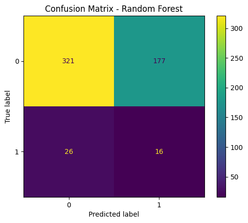

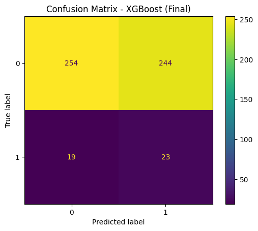

```python
from sklearn.metrics import confusion_matrix, ConfusionMatrixDisplay
import matplotlib.pyplot as plt

# Random Forest
cm_rf = confusion_matrix(y_test, y_pred_rf_final)
ConfusionMatrixDisplay(cm_rf).plot()
plt.title("Confusion Matrix - Random Forest")
plt.show()

# XGBoost (MODEL TERBAIK)
cm_xgb = confusion_matrix(y_test, y_pred_xgb_final)
ConfusionMatrixDisplay(cm_xgb).plot()
plt.title("Confusion Matrix - XGBoost (Final)")
plt.show()
```

### **Insight:**

**Model XGBoost** memiliki kemampuan deteksi LTI yang lebih baik dibandingkan Random Forest, ditunjukkan dengan jumlah true positive yang lebih tinggi (23 vs 16) dan false negative yang lebih rendah (19 vs 26); hal ini menunjukkan bahwa model lebih sensitif dalam menangkap kejadian LTI, meskipun menghasilkan jumlah false positive yang lebih besar.

Perbandingan confusion matrix menunjukkan bahwa XGBoost lebih unggul dalam mendeteksi kejadian LTI dengan jumlah true positive yang lebih tinggi dan false negative yang lebih rendah, sehingga lebih sesuai untuk tujuan keselamatan kerja. Namun demikian, model menghasilkan false positive yang cukup tinggi, yang menunjukkan adanya trade-off antara sensitivitas dan ketepatan prediksi.

### c) Bandingkan performa antar model dan pilih model terbaik berdasarkan metrik yang relevan untuk konteks SHE (prioritas: Recall tinggi untuk meminimalkan insiden yang terlewat)

```python
df_evaluasi.sort_values(by='Recall', ascending=False)
```

|  | Model | Accuracy | Precision | Recall | F1-Score | AUC-ROC |
| --- | --- | --- | --- | --- | --- | --- |
| 1 | XGBoost | 0.51 | 0.09 | 0.55 | 0.15 | 0.51 |
| 0 | Random Forest | 0.62 | 0.08 | 0.38 | 0.14 | 0.55 |

### d) Analisis feature importance: variabel apa yang paling berpengaruh terhadap prediksi LTI?

```
Hari_dalam_Minggu_Sunday          0.03
Hari_dalam_Minggu_Saturday        0.03
Jam_Kerja_safe                    0.03
Jenis_Pekerjaan_Survei            0.03
Area_Kerja_Rom (Run Of Mine)      0.03
Jenis_Pekerjaan_Grading           0.03
Jenis_Pekerjaan_Loading           0.03
Area_Kerja_Office Area            0.03
Jenis_Pekerjaan_Blasting          0.03
Penyebab_Utama_Komunikasi Buruk   0.02
dtype: float32
```

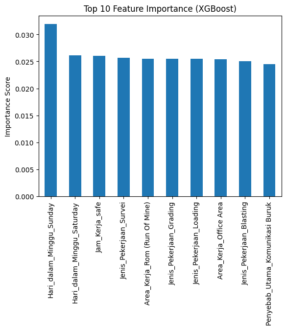

```python
import pandas as pd
import matplotlib.pyplot as plt

# gunakan XGBoost (model terbaik)
feature_importance = pd.Series(xgb.feature_importances_, index=X_train.columns)

top_features = feature_importance.sort_values(ascending=False).head(10)

print(top_features)

# Visualisasi
top_features.plot(kind='bar')
plt.title("Top 10 Feature Importance (XGBoost)")
plt.ylabel("Importance Score")
plt.show()
```

### **Insight:**

Analisis feature importance menunjukkan bahwa variabel yang paling berpengaruh terhadap kejadian LTI berasal dari kombinasi faktor temporal, operasional, dan lingkungan. Hal ini mengindikasikan bahwa risiko kecelakaan kerja bersifat multifaktor dan memerlukan pendekatan mitigasi yang menyeluruh, tidak hanya berfokus pada individu tetapi juga pada sistem kerja dan kondisi operasional.

### e) Susun rekomendasi strategis kepada manajemen PT. Banana Coal berdasarkan temuan model (mis. area/shift/penyebab yang perlu diprioritaskan dalam program intervensi SHE)

Berdasarkan hasil pemodelan, ditemukan bahwa:

- Kejadian LTI dipengaruhi oleh kombinasi faktor operasional, lingkungan, dan temporal.
- Model XGBoost menunjukkan kemampuan yang lebih baik dalam mendeteksi potensi insiden meskipun masih menghasilkan false positive yang cukup tinggi.
- Oleh karena itu, model ini dapat dimanfaatkan sebagai sistem peringatan dini (early warning system) untuk membantu manajemen dalam mengidentifikasi area berisiko tinggi dan melakukan intervensi secara proaktif.

**Rekomendasi Strategis:**

1. Peningkatan Pengawasan pada Hari Tertentu (Akhir Pekan)

Berdasarkan: Feature Importance (Saturday & Sunday)

Rekomendasi:

- Menambahkan safety briefing khusus pada akhir pekan.
- Meningkatkan pengawasan supervisor Evaluasi potensi kelelahan pekerja

2. Prioritas Area Operasional Berisiko Tinggi

Berdasarkan: EDA & Feature Importance (ROM, Pit, aktivitas operasional)

Rekomendasi:

- Melakukan audit keselamatan pada area ROM dan Pit
- Menambahkan SOP khusus untuk area berisiko tinggi
- Monitoring aktivitas operasional secara berkala

Alasan: Area operasional memiliki intensitas aktivitas tinggi sehingga berkontribusi besar terhadap potensi insiden.

3. Pengendalian Aktivitas Berisiko (Loading & Grading)

Berdasarkan: Feature Importance (Jenis_Pekerjaan)

Rekomendasi:

- Pelatihan ulang operator alat berat
- Pengawasan real-time saat aktivitas berlangsung
- Evaluasi prosedur kerja

Alasan: Aktivitas ini melibatkan alat berat dan interaksi kompleks yang meningkatkan potensi kecelakaan kerja.

4. Antisipasi Risiko pada Periode Tertentu (Kuartal 3)

Berdasarkan: Tren Kuartal

Rekomendasi:

- Program safety campaign sebelum Q3
- Penambahan tenaga pengawas
- Penjadwalan ulang pekerjaan berisiko tinggi

5. Pengendalian Faktor Lingkungan (Cuaca & Eksternal)

Rekomendasi:

- Menyusun SOP saat cuaca buruk
- Penundaan aktivitas berisiko tinggi
- Monitoring kondisi lapangan

Alasan: Faktor eksternal tidak dapat dikontrol, tetapi dampaknya dapat diminimalkan melalui kebijakan operasional.

6. Perbaikan Sistem Engineering & Prosedur

Berdasarkan: Penyebab utama (Desain/Engineering)

Rekomendasi:

- Review desain kerja dan sistem operasional
- Audit kepatuhan terhadap SOP
- Perbaikan sistem kerja

Alasan: Kecelakaan tidak hanya disebabkan oleh human error, tetapi juga oleh kelemahan sistem.

7. Implementasi Early Warning System (Berbasis Model)

Berdasarkan: Recall XGBoost = 0.55

Rekomendasi:

- Integrasi model ke dalam dashboard monitoring
- Penggunaan model sebagai alat deteksi dini
- Prioritas investigasi pada prediksi risiko tinggi

Model prediksi yang dibangun mampu memberikan insight berbasis data terkait faktor-faktor yang mempengaruhi kejadian LTI, serta dapat digunakan sebagai sistem peringatan dini untuk membantu perusahaan dalam melakukan intervensi keselamatan kerja secara lebih efektif dan tepat sasaran.

```python
# Simpan Dataset bersih
df.to_csv('data_bersih.csv', index=False)
```

```python
# Simpan Model
import joblib

joblib.dump(rf, 'model_random_forest.pkl')
joblib.dump(xgb, 'model_xgboost.pkl')
```

```
['model_xgboost.pkl']
```

```python
# Simpan threshold & fitur
joblib.dump(best_threshold, 'threshold_xgb.pkl')
joblib.dump(X_train.columns.tolist(), 'fitur_model.pkl')
```

```
['fitur_model.pkl']
```

```python
# TUJUAN:
# Mengubah notebook Colab (.ipynb) menjadi file HTML, lalu otomatis download ke laptop.

from google.colab import drive, files
import os
import sys
import subprocess

# 1. Hubungkan Colab ke Google Drive
drive.mount('/content/drive')

# 2. GANTI nama file notebook di bawah ini sesuai nama notebook kamu
notebook_path = "/content/drive/MyDrive/Colab Notebooks/Salinan dari Sertifikasi BNSP_Data Scientist.ipynb"

# 3. Nama file HTML hasil export
output_dir = "/content"
output_name = "Sertifikasi BNSP - Data Scientist"

# 4. Cek apakah file notebook ditemukan
if not os.path.exists(notebook_path):
    raise FileNotFoundError(
        f"Notebook tidak ditemukan:\n{notebook_path}\n\n"
        "Pastikan nama file dan lokasi folder sudah benar."
    )

# 5. Install nbconvert jika belum tersedia
subprocess.run(
    [sys.executable, "-m", "pip", "install", "-q", "nbconvert"],
    check=True
)

# 6. Convert notebook menjadi HTML
subprocess.run(
    [
        "jupyter", "nbconvert",
        "--to", "html",
        notebook_path,
        "--output-dir", output_dir,
        "--output", output_name
    ],
    check=True
)

# 7. Download file HTML
html_path = f"{output_dir}/{output_name}.html"

print("File HTML berhasil dibuat:")
print(html_path)

files.download(html_path)
```